# R Notebook for MDR S-map for DE and ODE models version 3

### [0] Packages loading

rEDM should be the version 1.2.3

https://cran.r-project.org/src/contrib/Archive/rEDM/

```r
library(mathjaxr)
library(rEDM); packageVersion("rEDM")
```

```
[1] ‘1.2.3’
```

```r
library(parallel)
library(doParallel)
library(foreach)
library(Kendall)
library(MASS)
library(dplyr)
library(glmnet)
library(ggplot2)
#source("../Demo_MDR_function.R")
source("./Demo_MDR_function2.R") #from 2024/05/07
```

### [1] General functions for ODEs

4th-order explicit Runge-Kutta method with a fixed interval function

```r
rk4 <- function(in_vec, ref_data = NULL, time, h_interval, dim, diff_vec)
{
  #in_vec: the vector with the value at "time"
  #out_vec: the vector with which the updated vector value after one time step is saved
  #time: time value
  #h_interval: time step for discritizing ODE
  #dim: dimension of the ODE
  #diff_vec: function that determines the r.h.s. of the ODE

  k1 <- numeric(dim)
  k2 <- numeric(dim)
  k3 <- numeric(dim)
  k4 <- numeric(dim)
  temp_vec <- numeric(dim)
  h_half <- h_interval / 2.0
  t_h <- time + h_half

  k1 <- diff_vec(in_vec, ref_data, time, h_interval, dim)  # calculate k1
  temp_vec <- in_vec + h_half * k1
  k2 <- diff_vec(temp_vec, ref_data, t_h, h_interval, dim)  # calculate k2
  temp_vec <- in_vec + h_half * k2
  k3 <- diff_vec(temp_vec, ref_data, t_h, h_interval, dim)  # calculate k3
  temp_vec <- in_vec + h_interval * k3
  k4 <- diff_vec(temp_vec, ref_data, time + h_interval, h_interval, dim)  # calculate k4

  temp_vec <- in_vec + (h_interval / 6.0) * (k1 + 2.0 * k2 + 2.0 * k3 + k4)
  temp_vec
}
```

### [2] Model01 setting

Note: When the natural mortality goes to infinity, the model converges to 2-Host 2-Parasitoid Nicolson-Baily Model

$$H_{k,t+1} = H_{k,t} + r_k exp[-a_{k}H_{k,t} - c_{1k} P_{1,t} - c_{2k}
P_{2, t}] H_{k,t} - (1 - exp[-a_{k}H_{k,t} - c_{1k} P_{1,t} - c_{2k}
P_{2,t} - m_{H,k}]) H_{k,t} \quad (k=1,2) \tag{D1}$$
It is set as
$$H_{k,t+1} = H_{k,t} + F_{Hk}(H_{1,t}, H_{2,t}, P_{1,t}, P_{2,t})$$

$$P_{j,t+1} = P_{j,t} + \sum_{k=1,2} exp(-a_k H_{k,t}) (1 - exp[-c_{1k}
P_{1,t} - c_{2k} P_{2,t}]) \frac{c_{jk} P_{j,t}}{c_{1k} P_{1,t} + c_{2k}
P_{2,t}} H_{k,t} -(1 - exp(-m_{P,j})) P_{j,t} \quad (j=1,2) \tag{D2}$$
It is set as
$$P_{j,t+1} = P_{j,t} + F_{Pj}(H_{1,t}, H_{2,t}, P_{1,t}, P_{2,t})$$

#### [2.2] Parameters and settings for the 4-species coupled host-parasitoid model

##### [2.2.1] Parameter value setting

```r
r1 <- 2.0
r2 <- 2.0
a1 <- 0.1
a2 <- 0.1
c11 <- 0.3 #P1 -> H1
c21 <- 0.1 #P2 -> H1
c12 <- 0.1 #P1 -> H2
c22 <- 0.3 #P2 -< H2
mH1 <- 0.1
mH2 <- 0.1
mP1 <- 0.1
mP2 <- 0.1
```

##### [2.2.2] Setting for numerical calculations

```r
j_Host1 <- 1
j_Host2 <- 2
j_Paras1 <- 3
j_Paras2 <- 4
```

##### [2.2.3] Functions specific to 4-sp model

Note that FH1, FH2, FP1, FP2, are defined as the changes of the abundance (X_t+1 - X_t)

```r
FH1 <- function(in_vec, t) {
  term1 <- r1*exp(-a1 * in_vec[j_Host1] - c11 * in_vec[j_Paras1] - c21 * in_vec[j_Paras2]) * in_vec[j_Host1]
  term2 <- (1.0 - exp(-a1 * in_vec[j_Host1] - c11 * in_vec[j_Paras1] - c21 * in_vec[j_Paras2] - mH1)) * in_vec[j_Host1]
  return(term1 - term2)
}

FH2 <- function(in_vec, t) {
  term1 <- r2*exp(-a2 * in_vec[j_Host2] - c12 * in_vec[j_Paras1] - c22 * in_vec[j_Paras2]) * in_vec[j_Host2]
  term2 <- (1.0 - exp(-a2 * in_vec[j_Host2] - c12 * in_vec[j_Paras1] - c22 * in_vec[j_Paras2] - mH2)) * in_vec[j_Host2]
  return(term1 - term2)
}

FP1 <- function(in_vec, t) {
  term1 <- exp(-a1 * in_vec[j_Host1]) * (1 - exp(-c11 * in_vec[j_Paras1] - c21 * in_vec[j_Paras2])) * c11 * in_vec[j_Paras1] / (c11 * in_vec[j_Paras1] + c21 * in_vec[j_Paras2]) * in_vec[j_Host1]

  term2 <- exp(-a2 * in_vec[j_Host2]) * (1 - exp(-c12 * in_vec[j_Paras1] - c22 * in_vec[j_Paras2])) * c12 * in_vec[j_Paras1] / (c12 * in_vec[j_Paras1] + c22 * in_vec[j_Paras2]) * in_vec[j_Host2]

  term3 <- (1.0 - exp(- mP1)) * in_vec[j_Paras1]
  return(term1 + term2 - term3)
}

FP2 <- function(in_vec, t) {
  term1 <- exp(-a1 * in_vec[j_Host1]) * (1 - exp(-c11 * in_vec[j_Paras1] - c21 * in_vec[j_Paras2])) * c21 * in_vec[j_Paras2] / (c11 * in_vec[j_Paras1] + c21 * in_vec[j_Paras2]) * in_vec[j_Host1]

  term2 <- exp(-a2 * in_vec[j_Host2]) * (1 - exp(-c12 * in_vec[j_Paras1] - c22 * in_vec[j_Paras2])) * c22 * in_vec[j_Paras2] / (c12 * in_vec[j_Paras1] + c22 * in_vec[j_Paras2]) * in_vec[j_Host2]

  term3 <- (1.0 - exp(- mP2)) * in_vec[j_Paras2]
  return(term1 + term2 - term3)
}

#function to calculate all changes four dimensional
diff_4HP <- function(in_vec, t, dim){
  temp_vec <- numeric(dim)
  temp_vec[j_Host1] <- FH1(in_vec, t)
  temp_vec[j_Host2] <- FH2(in_vec, t)
  temp_vec[j_Paras1] <- FP1(in_vec, t)
  temp_vec[j_Paras2] <- FP2(in_vec, t)
  temp_vec
}
```

##### [2.2.4] Initial setting and conditions

```r
dim_model2 <- 4
nv_4HP0 <- numeric(dim_model2)
nv_4HP <- numeric(dim_model2)

nv_4HP0[j_Host1] <- 1.0
nv_4HP0[j_Host2] <- 1.0
nv_4HP0[j_Paras1] <- 0.1
nv_4HP0[j_Paras2] <- 0.1
```

#### [2.3] Solving the model

##### [2.3.1] Trial with a single Host - single Parasitoid system

```r
t <- 0  # initial condition (initial time, 0)
end_time <- 1000

#Setting initial condition
nv_4HP[j_Host1] <- 1.0
nv_4HP[j_Host2] <- 0.0
nv_4HP[j_Paras1] <- 0.1
nv_4HP[j_Paras2] <- 0.0


# write initial condition
cat(t, nv_4HP, "\n")
```

```
0 1 0 0.1 0
```

```r
# record the initial condition
HP_result <- data.frame(t = t, H1 = nv_4HP[j_Host1], H2 = nv_4HP[j_Host2], P1 = nv_4HP[j_Paras1], P2 = nv_4HP[j_Paras2])
#For the transient dynamics (RUN BURN)
for(i in 1:end_time){
  nv_4HP <- nv_4HP + diff_4HP(nv_4HP, t, dim_model2)
  t <- t + 1 #update time
  HP_result <- rbind.data.frame(HP_result, c(t, nv_4HP[j_Host1], nv_4HP[j_Host2], nv_4HP[j_Paras1], nv_4HP[j_Paras2]))
}

head(HP_result)
```

|  | t | H1 | H2 | P1 | P2 |
| --- | --- | --- | --- | --- | --- |
| 1 | 0 | 1.000000 | 0 | 0.1000000 | 0 |
| 2 | 1 | 2.550724 | 0 | 0.1172257 | 0 |
| 3 | 2 | 5.542883 | 0 | 0.1743696 | 0 |
| 4 | 3 | 8.778389 | 0 | 0.3200669 | 0 |
| 5 | 4 | 9.629308 | 0 | 0.6236902 | 0 |
| 6 | 5 | 8.856494 | 0 | 1.1916642 | 0 |

```r
#Trial of the plot
plot(HP_result$t, HP_result$H1, type = "l", ylim = c(0,20))
par(new = T)
```

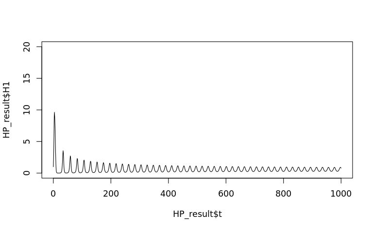

```r
plot(HP_result$t, HP_result$P1, type = "l", ylim = c(0,20), col = "red")
```

##### [2.3.2] Trial with two pairs of Host - Parasitoid system

```r
t <- 0  # initial condition (initial time, 0)
end_time <- 2000

#Setting initial condition; it is important to start with asymmetric densities to reach quickly the chaotic attractor
nv_4HP[j_Host1] <- 1.0
nv_4HP[j_Host2] <- 0.5
nv_4HP[j_Paras1] <- 0.1
nv_4HP[j_Paras2] <- 0.2


# write initial condition
cat(t, nv_4HP, "\n")
```

```
0 1 0.5 0.1 0.2
```

```r
# record the initial condition
HP_result <- data.frame(t = t, H1 = nv_4HP[j_Host1], H2 = nv_4HP[j_Host2], P1 = nv_4HP[j_Paras1], P2 = nv_4HP[j_Paras2])
#For the transient dynamics (RUN BURN)
for(i in 1:end_time){
  nv_4HP <- nv_4HP + diff_4HP(nv_4HP, t, dim_model2)
  t <- t + 1 #update time
  HP_result <- rbind.data.frame(HP_result, c(t, nv_4HP[j_Host1], nv_4HP[j_Host2], nv_4HP[j_Paras1], nv_4HP[j_Paras2]))
}

head(HP_result)
```

|  | t | H1 | H2 | P1 | P2 |
| --- | --- | --- | --- | --- | --- |
| 1 | 0 | 1.000000 | 0.500000 | 0.1000000 | 0.2000000 |
| 2 | 1 | 2.500217 | 1.288180 | 0.1215549 | 0.2261803 |
| 3 | 2 | 5.331586 | 3.036726 | 0.1921650 | 0.3212706 |
| 4 | 3 | 8.306937 | 5.800170 | 0.3870404 | 0.5908329 |
| 5 | 4 | 8.824918 | 7.601106 | 0.8487889 | 1.2484865 |
| 6 | 5 | 7.257095 | 6.521704 | 1.7835976 | 2.5764024 |

```r
#Trial of the plot
plot(HP_result$t, HP_result$H1, type = "l", ylim = c(0,5))
par(new = T)
```

```r
plot(HP_result$t, HP_result$P1, type = "l", ylim = c(0,5), col = "red")
par(new = T)
```

```r
plot(HP_result$t, HP_result$H2, type = "l", ylim = c(0,5), lty = "dashed")
par(new = T)
```

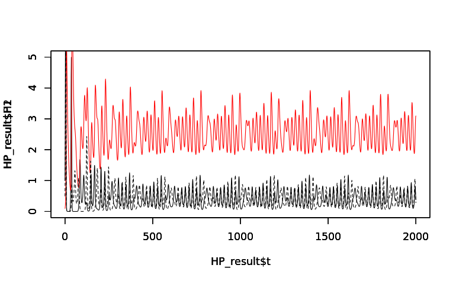

```r
plot(HP_result$t, HP_result$P2, type = "l", ylim = c(0,5), col = "red", lty = "dashed")
```

```r
DAY = Sys.Date()
saveRDS(HP_result, paste("HP4p_result_", DAY, ".obj", sep = ""))
```

### [3] A simple analysis with multivariate S-map

Based on https://ushio-ecology-blog.blogspot.com/2019/12/20191225blogger0007.html

#### [3.1] Analysis with standardization

```r
HP_result <- readRDS("HP4p_result_2024-07-25.obj")
HP_result <- HP_result[1801:2000, ]
```

##### [3.1.1] Standardization

```r
HP_result.mean <- apply(HP_result[, -1], 2, mean, na.rm = T)  # mean abundance
HP_result.sd <- apply(HP_result[, -1], 2, sd, na.rm = T)      # SD of abundance

mean_mat <- matrix(HP_result.mean, nrow = nrow(HP_result) , ncol = length(HP_result.mean), byrow = TRUE)
sd_mat <- matrix(HP_result.sd, nrow = nrow(HP_result) , ncol = length(HP_result.mean), byrow = TRUE)

HP_result_s <- (HP_result[, -1] - mean_mat) /sd_mat # Standardized data set
head(HP_result_s)
```

|  | H1 | H2 | P1 | P2 |
| --- | --- | --- | --- | --- |
| 1801 | -0.7075075 | -0.3006960 | 2.4418952 | 0.9240188 |
| 1802 | -0.9981397 | -0.5921074 | 2.1191480 | 0.7495604 |
| 1803 | -1.1700690 | -0.7798881 | 1.7051327 | 0.4924579 |
| 1804 | -1.2688669 | -0.8888591 | 1.2546247 | 0.1943029 |
| 1805 | -1.3221486 | -0.9378157 | 0.8015959 | -0.1156764 |
| 1806 | -1.3448846 | -0.9369800 | 0.3660611 | -0.4179222 |

##### [3.1.2] Analysis with the standardized time series data

```r
# data block for smap
HP_smap_block_s <- data.frame(H1 = HP_result_s$H1, H2 = HP_result_s$H2, P1 = HP_result_s$P1, P2 = HP_result_s$P2)

# delete a few column
# conducting smap for obtaining the optimal theta
HP_m_smap_res_s <- block_lnlp(HP_smap_block_s, method = "s-map",
                         target_column = j_Host1,
                         theta = c(0, 1e-04, 3e-04, 0.001, 0.003, 0.01, 0.03, 0.1, 0.3, 0.5, 0.75, 1, 1.5, 2, 3, 4, 6, 8),
                         silent = TRUE)
```

Plotting the effect of theta

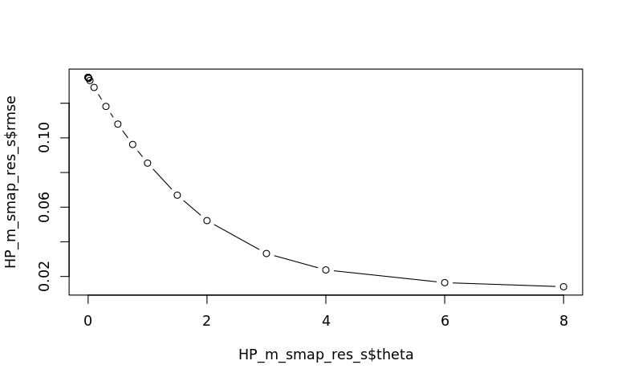

```r
plot(HP_m_smap_res_s$theta, HP_m_smap_res_s$rmse, type = "b")
```

```r
(HP_opt_theta_s <- HP_m_smap_res_s$theta[which.min(HP_m_smap_res_s$rmse)])
```

```
[1] 8
```

Conducting smap with the optimal theta

```r
HP_m_smap_res2_s <- block_lnlp(HP_smap_block_s, method = "s-map",
                              target_column = j_Host1,
                              theta = HP_opt_theta_s,
                              silent = TRUE,
                              save_smap_coefficients = TRUE)
head(as.data.frame(HP_m_smap_res2_s$smap_coefficients[[1]]))
```

|  | c_1 | c_2 | c_3 | c_4 | c_0 |
| --- | --- | --- | --- | --- | --- |
| 1 | 0.7308779 | -0.015145894 | -0.10088670 | -0.03264434 | -0.21543005 |
| 2 | 0.7804473 | -0.023967869 | -0.09028076 | -0.02901144 | -0.20732322 |
| 3 | 0.8349041 | -0.029205775 | -0.07051304 | -0.02697060 | -0.19115280 |
| 4 | 0.8953152 | -0.023353581 | -0.05879584 | -0.02853115 | -0.13293146 |
| 5 | 0.9517976 | -0.011428545 | -0.05664668 | -0.02646521 | -0.05740506 |
| 6 | 1.0114218 | -0.001824384 | -0.06182678 | -0.02338683 | 0.02612927 |

##### [3.1.3] Plotting the results

```r
final_ID <- 200
delta_11 <- 1
plot(HP_result$t[-final_ID], HP_m_smap_res2_s$smap_coefficients[[1]]$c_1[-final_ID] - delta_11, type = "l", col = 1, ylim = c(-0.9, 1.0), xlab = "time", ylab = "Smap coefficient: X -> Host1", main = "S-map for H1")
par(new = T)
```

```r
plot(HP_result$t[-final_ID], HP_m_smap_res2_s$smap_coefficients[[1]]$c_2[-final_ID], type = "l", col = "red", ylim = c(-0.9, 1.0), xlab = "", ylab = "")
par(new = T)
```

```r
plot(HP_result$t[-final_ID], HP_m_smap_res2_s$smap_coefficients[[1]]$c_3[-final_ID], type = "l", col = "blue", ylim = c(-0.9, 1.0), xlab = "", ylab = "")
par(new = T)
```

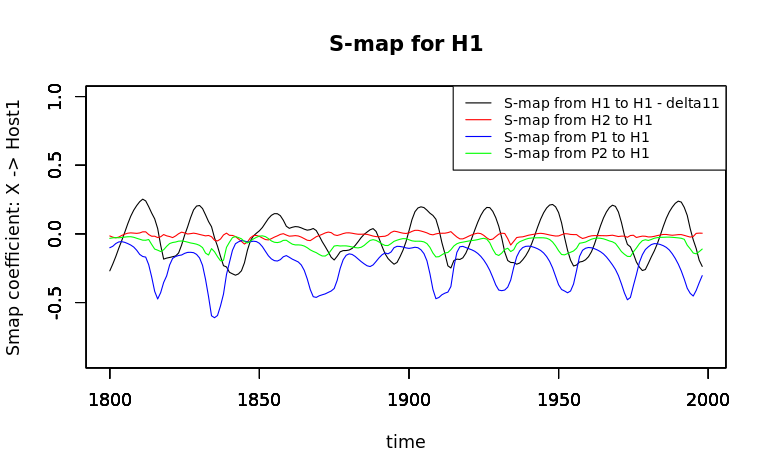

```r
plot(HP_result$t[-final_ID], HP_m_smap_res2_s$smap_coefficients[[1]]$c_4[-final_ID], type = "l", col = "green", ylim = c(-0.9, 1.0), xlab = "", ylab = "")

legend("topright",
          legend = c("S-map from H1 to H1 - delta11", "S-map from H2 to H1", "S-map from P1 to H1", "S-map from P2 to H1"),
          col = c("black", "red", "blue", "green"),
          lty = c(1, 1, 1, 1),
          cex = 0.8)
```

##### [3.1.4] Plotting the results for manuscript (Fig.1)

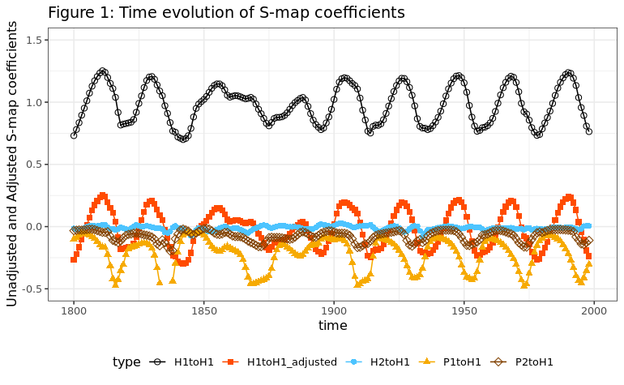

```r
gg_HP_result00 <- data.frame(time = HP_result$t[-final_ID], smap = HP_m_smap_res2_s$smap_coefficients[[1]]$c_1[-final_ID], type = rep("H1toH1", 199))
gg_HP_result01 <- data.frame(time = HP_result$t[-final_ID], smap = HP_m_smap_res2_s$smap_coefficients[[1]]$c_1[-final_ID] - delta_11, type = rep("H1toH1_adjusted", 199))
gg_HP_result02 <- data.frame(time = HP_result$t[-final_ID], smap = HP_m_smap_res2_s$smap_coefficients[[1]]$c_2[-final_ID], type = rep("H2toH1", 199))
gg_HP_result03 <- data.frame(time = HP_result$t[-final_ID], smap = HP_m_smap_res2_s$smap_coefficients[[1]]$c_3[-final_ID], type = rep("P1toH1", 199))
gg_HP_result04 <- data.frame(time = HP_result$t[-final_ID], smap = HP_m_smap_res2_s$smap_coefficients[[1]]$c_4[-final_ID], type = rep("P2toH1", 199))

gg_HP_result <- rbind.data.frame(gg_HP_result00, gg_HP_result01)
gg_HP_result <- rbind.data.frame(gg_HP_result, gg_HP_result02)
gg_HP_result <- rbind.data.frame(gg_HP_result, gg_HP_result03)
gg_HP_result <- rbind.data.frame(gg_HP_result, gg_HP_result04)


fig1_ggplot <- ggplot(data = gg_HP_result) +
  scale_colour_manual(values = c("black", "#ff4b00","#4dc4ff", "#f6aa00", "#804000")) +
  scale_shape_manual(values = c(1, 15, 16, 17, 5)) +
　geom_line(aes(x = time, y = smap, group = type, color = type)) +
  geom_point(aes(x = time, y = smap, color = type, shape = type), size = 2) +
  xlim(1800, 1999) +  ylim(-0.5, 1.5) + theme_bw() + theme(legend.position = "bottom") +
  labs(title = "Figure 1: Time evolution of S-map coefficients", x = "time", y = "Unadjusted and Adjusted S-map coefficients")
plot(fig1_ggplot)
ggsave("fig1_ggplot.pdf", width = 10, height = 5)
```

### [4] MDR S-map for 2host-2parasitoid system

Applying MDR S-map to the 4sp coupled host-parasitoid model

#### [4.1] Data prearrangement

Read dataset

```r
da.range <- 1801:2000 # Subsample for data analysis
out.sample <- T # T/F for out-of-sample forecast
nout <- 2  # number of out-of-sample

da.name <- '4p_model'
do <- readRDS("HP4p_result_2024-07-25.obj")
dot <- do[da.range, 1] # data time
do <- do[da.range, -1] # subset of data without t
ndo <- nrow(do)
nin <- ndo - nout # library sample size
```

Standardization

```r
# In-sample
do.mean <- apply(do[1:nin, ], 2, mean, na.rm = T)  # mean abundance in in-sample
do.sd <- apply(do[1:nin, ], 2, sd, na.rm = T)      # SD of abundance in in-sample
d <- do[1:(nin-1), ]                          # In-sample dataset at time t
d_tp1 <- do[2:(nin), ]                        # In-sample dataset at time t+1
ds <- (d - repmat(do.mean, nrow(d), 1))*repmat(do.sd, nrow(d), 1) ^ -1 # Normalized in-sample dataset at time t
ds_tp1 <- (d_tp1 - repmat(do.mean, nrow(d_tp1), 1))*repmat(do.sd, nrow(d_tp1), 1) ^ -1 # Normalized in-sample dataset at time t+1

# Out-sample
if(out.sample & nout != 0){
  d.test <- do[nin:(ndo - 1), ]                 # Out-of-sample dataset at time t
  dt_tp1 <- do[(nin + 1): ndo, ]                 # Out-of-sample dataset at time t+1
  ds.test <- (d.test - repmat(do.mean, nrow(d.test), 1))*repmat(do.sd, nrow(d.test), 1) ^ -1 # Normalized out-of-sample dataset at time t
  dst_tp1 <- (dt_tp1 - repmat(do.mean, nrow(dt_tp1), 1))*repmat(do.sd, nrow(dt_tp1), 1) ^ -1 # Normalized out-of-sample dataset at time t+1
}else{d.test <- dt_tp1 <- ds.test <- NULL}

# Compiled data at time t
ds.all <- rbind(ds, ds.test)
head(ds.all)
```

|  | H1 | H2 | P1 | P2 |
| --- | --- | --- | --- | --- |
| 1801 | -0.6988979 | -0.2954871 | 2.4510002 | 0.96668747 |
| 1802 | -0.9889209 | -0.5858864 | 2.1283344 | 0.78852338 |
| 1803 | -1.1604898 | -0.7730150 | 1.7144235 | 0.52595990 |
| 1804 | -1.2590806 | -0.8816075 | 1.2640292 | 0.22147185 |
| 1805 | -1.3122506 | -0.9303941 | 0.8111146 | -0.09509168 |
| 1806 | -1.3349389 | -0.9295613 | 0.3756897 | -0.40375739 |

Initialization of pseudo-random number generator

```r
seed <- 49563
set.seed(seed)
```

#### [4.2] Optimal embedding dimension

Find the optimal embedding dimension, based on univariate simplex projection

```r
Emax <- 4 # equal to or smaller than the number of nodes (dimension of the DE system)
cri <- 'rmse' # model selection
Ed <- NULL
forecast_skill_simplex <- NULL
for(i in 1:ncol(ds)){
  spx.i <- simplex(ds[, i], E = 2:Emax)
  Ed <- c(Ed, spx.i[which.min(spx.i[, cri])[1], 'E'])
  forecast_skill_simplex <- c(forecast_skill_simplex, spx.i[which.min(spx.i[, cri])[1], 'rho'])
}
Ed # The optimal embedding dimension for each variable
```

```
[1] 2 3 2 2
```

Optimal embedding dimension and forecasting skill

```r
Ed
```

```
[1] 2 3 2 2
```

```r
forecast_skill_simplex
```

```
[1] 0.9882117 0.9882610 0.9917444 0.9875901
```

#### [4.3] CCM analysis

- Find causal variables by CCM analysis that will be used for multiview embedding.
- Warning: It is time consuming for calculating the causation for each node
- CCM causality test for all node pairs (the function was updated at 2024/05/07)

```r
ccm.out <- ccm.fast.demo(ds, Epair = T, cri = cri, Emax = Emax)
ccm.sig <- ccm.out[['ccm.sig']]
ccm.rho <- ccm.out[['ccm.rho']]
#To avoid overwrite the original files, we save them with different names,identified by date.
DAY = Sys.Date()
saveRDS(ccm.sig, paste('ccm_sig', da.name,'nin', nin, DAY, '.obj', sep = '_'))
saveRDS(ccm.rho, paste('ccm_rho', da.name,'nin', nin, DAY, 'demo.obj', sep = '_'))
```

Just in case not conducting CCM but just loading the result of CCM at 2024/07/29

```r
DAY = "2024-07-29"
ccm.sig_old <- readRDS(paste('ccm_sig', da.name,'nin', nin, DAY, '.obj', sep = '_'))
ccm.rho_old <- readRDS(paste('ccm_rho', da.name,'nin', nin, DAY, 'demo.obj', sep = '_'))
```

```r
ccm.sig
```

```
     [,1] [,2] [,3] [,4]
[1,]    1    1    1    1
[2,]    1    1    1    1
[3,]    1    1    1    1
[4,]    1    1    1    1
```

```r
ccm.rho
```

```
          [,1]      [,2]      [,3]      [,4]
[1,] 0.9968866 0.4473342 0.9284430 0.5018034
[2,] 0.3379242 0.9957334 0.5413753 0.8980526
[3,] 0.9220910 0.4914316 0.9979308 0.4655782
[4,] 0.4084419 0.9041382 0.3693686 0.9952968
```

#### [4.4] Multiview distance

##### [4.4.1] Performing multiview analysis

Based on the causal variables detected in CCM,

1. generates the time lag series (with maximum lag = 3),
2. conduct multivariate simplex projection and evaluate the forecast skill, and
3. selected the best kn(=100) SSR.

Perform multiview embedding analysis for each node

Warning: It is time consuming for running multiview embedding for each nodes

```r
esele_lag <- esim.lag.demo(ds, ccm.rho, ccm.sig, Ed, kmax = 10000, kn = 100, max_lag = 3, Emax = Emax)
# To avoid overwrite the original files, we save them with different names, 'XXX_NEW'.
DAY = Sys.Date()
saveRDS(esele_lag, paste('eseleLag', da.name, 'nin', nin, DAY, 'demo.obj', sep='_'))
```

The list of the selected best multivariate SSRs for each node (species, sp) with

```r
as.data.frame(esele_lag)
```

[output not shown]

##### [4.4.2] Compute multiview distance

```r
dmatrix.mv <- mvdist.demo(ds, ds.all, esele_lag)
dmatrix.train.mvx <- dmatrix.mv[['dmatrix.train.mvx']]
dmatrix.test.mvx <- dmatrix.mv[['dmatrix.test.mvx']]
```

Leave-one-out cross-validation for finding the optimal parameters for MDR S-map analysis

–Warning: The cross-validation is the most time-consuming step in MDR S-map requiring massive computations and . Thus, we recommend dividing job into smaller parts (sub.da>1) or used parallel computation (parall=T, ncore>=1)

```r
do.MDR.CV <- T
### The parameter cv.unit determines the precision of selected parameters and strongly influences computation time.
### In our cases, we used cv.unit=0.025 to obtain more precise estimations
### This parameter may be adjusted to 0.05 or even 0.1, depending on how sensitive the results to parameter precision.
cv.unit <- 0.025
alpha.so <- seq(0, 1, cv.unit);            # Sequence of alpha
sub.da <- 1                                # Divide the computation job into five parts
afsp <- eqsplit(1:length(alpha.so), sub.da) # Divide the parameter space based on alpha parameter
alf <- 1                                   # Run CV in the first parameter subset

# Cross-validation of MDR analysis
if(do.MDR.CV){
  alpha.s <- alpha.so[afsp[alf, 1]:afsp[alf, 2]] # Subset parameter space
  cv.ind <- cv.MDR.demo(ds, ds_tp1, dmatrix.list = dmatrix.train.mvx,
                        parall = T, ncore = 24, keep_intra = T,alpha.seq = alpha.s)
  # To avoid overwrite the original files, we save them with different names, 'XXX_NEW'.
  saveRDS(cv.ind, paste(da.name, 'nin', nin, 'cvunit', cv.unit, 'alph', alpha.s[1]*100, DAY, 'cvout_Nmvx_Rallx.obj', sep = '_'))
}
```

##### [4.4.3] Selecting the optimal parameters

Select the optimal parameter set for regularized regression model with the minimal MSE

```r
paracv.demo <- secv.demo(cv.ind)
paracv.demo
```

[output not shown]

#### [4.5] MDR S-map

Fitting MDR S-map based on the parameters selected by CV

Note that the linear regression model in MDR S-map includes all of variables as X even if some of them were not selected as the causal variables at the step of using CCM. This is reasonable because S-map coefficients represent the effects of variables at short timescale while CCM evaluates the causality in the whole period of the time series.

```r
#Setting
do.MDR <- F
cv.unit <- 0.025
ptype <- 'aenet'          #enet:elastic-net or msaenet: adaptive elastic-net

#Fitting the MDR S-map
smap.2H2P <- MDRsmap.demo(paracv = paracv.demo, ptype = ptype, keep_intra = T, out.sample = T,
                            ds,ds_tp1,ds.test,dst_tp1,
                            dmatrix.list = dmatrix.train.mvx,
                            dmatrix.test.list = dmatrix.test.mvx)
```

In case for saving the results

```r
DAY = Sys.Date()
nr.out <- smap.2H2P[['nr.out']];

  saveRDS(nr.out, paste(da.name,'_nin', nin, 'cvunit', cv.unit, ptype, DAY, 'nrout_Nmvx_Rallx_demo_NEW.obj',sep = '_'))
    # Save interaction Jacobian matrices at all time points
  saveRDS(smap.2H2P[['jcof']], paste(da.name,'nin', nin, 'cvunit', cv.unit, ptype, DAY, '_jcof_Nmvx_Rallx_demo_NEW.obj', sep='_'))
```

S-map coefficients

```r
smap.2H2P[['jcof']]
```

| Insample | time | variable | j0 | H1 | H2 | P1 | P2 |
| --- | --- | --- | --- | --- | --- | --- | --- |
| 1 | 1 | 1 | 3.851785e-04 | 0.953218349 | 0.000000e+00 | -0.1272521867 | -0.0512534774 |
| 1 | 1 | 2 | -8.647471e-04 | 0.000000000 | 8.291358e-01 | -0.0635388637 | -0.2001879523 |
| 1 | 1 | 3 | -5.597373e-04 | 0.216133236 | 0.000000e+00 | 0.9473541246 | 0.0000000000 |
| 1 | 1 | 4 | 2.537843e-04 | 0.061444400 | 2.296316e-01 | 0.0000000000 | 0.9590186363 |
| 1 | 2 | 1 | 1.217102e-03 | 0.975866710 | 0.000000e+00 | -0.0935878364 | -0.0321573433 |
| 1 | 2 | 2 | -1.125106e-03 | 0.000000000 | 8.630483e-01 | -0.0623223099 | -0.1856897870 |
| 1 | 2 | 3 | -3.245353e-04 | 0.196703845 | 2.740291e-02 | 0.9295818036 | 0.0000000000 |
| 1 | 2 | 4 | 2.190567e-04 | 0.073220851 | 2.211777e-01 | 0.0000000000 | 0.9485754199 |
| 1 | 3 | 1 | 2.111217e-03 | 0.973400137 | 0.000000e+00 | -0.0894985464 | -0.0390448922 |
| 1 | 3 | 2 | -1.224115e-03 | 0.000000000 | 9.145848e-01 | -0.0542354107 | -0.1617052713 |

[output cut: 786 more lines]

#### [4.6] Compare S-map coefficients and theoretical benchmark

Loading data

```r
smap.2H2P[['jcof']] <- readRDS("4p_model_nin_198_cvunit_0.025_aenet_2024-07-31__jcof_Nmvx_Rallx_demo_NEW.obj")
```

##### [4.6.1] Compare multivariate S-map and MDR S-map

```r
final_ID <- 200
delta_11 <- 1

MDR_Smap_dH1dH1 <- subset(smap.2H2P[['jcof']], variable == j_Host1)[1:199, 5] - delta_11
MDR_Smap_dH1dH2 <- subset(smap.2H2P[['jcof']], variable == j_Host1)[1:199, 6]
MDR_Smap_dH1dP1 <- subset(smap.2H2P[['jcof']], variable == j_Host1)[1:199, 7]
MDR_Smap_dH1dP2 <- subset(smap.2H2P[['jcof']], variable == j_Host1)[1:199, 8]

plot(HP_result$t[-final_ID], HP_m_smap_res2_s$smap_coefficients[[1]]$c_1[-final_ID] - delta_11, type = "l", col = 1, ylim = c(-0.9, 1.0), xlab = "time", ylab = "Interation coefficients")
par(new = T)
```

```r
plot(HP_result$t[-final_ID], HP_m_smap_res2_s$smap_coefficients[[1]]$c_2[-final_ID], type = "l", col = "red", ylim = c(-0.9, 1.0), xlab = "", ylab = "")
par(new = T)
```

```r
plot(HP_result$t[-final_ID], HP_m_smap_res2_s$smap_coefficients[[1]]$c_3[-final_ID], type = "l", col = "blue", ylim = c(-0.9, 1.0), xlab = "", ylab = "")
par(new = T)
```

```r
plot(HP_result$t[-final_ID], HP_m_smap_res2_s$smap_coefficients[[1]]$c_4[-final_ID], type = "l", col = "green", ylim = c(-0.9, 1.0), xlab = "", ylab = "")
par(new = T)
```

```r
plot(HP_result$t[-final_ID], MDR_Smap_dH1dH1, type = "l", col = "brown", ylim = c(-0.9, 1.0), xlab = "", ylab = "")
par(new = T)
```

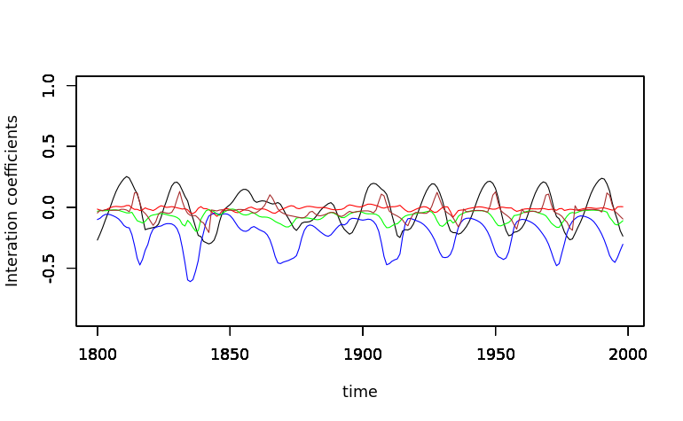

```r
plot(HP_result$t[-final_ID], MDR_Smap_dH1dP1, type = "l", col = "cyan", ylim = c(-0.9, 1.0), xlab = "", ylab = "")

legend("topright",
          legend = c("S-map from H1 to H1 - delta11", "S-map from H2 to H1", "S-map from P1 to H1", "S-map from P2 to H1","MDR S-map from H1 to H1 - delta11", "MDR S-map from P1 to H1"),
          col = c("black", "red", "blue", "green", "brown", "cyan"),
          lty = c(1, 1, 1, 1, 1, 1),
          cex = 0.8)
```

##### [4.6.2] List of theoretical Jacobian

$$\frac{\partial F_{H,i}}{\partial H_{i,k}} = -1 + (1 - a_i H_i) e ^ {-a_i
H_i - c_{1i} P_1 - c_{2i} P_2} (r_i + e ^{-m_{H,i}})$$
$$\frac{\partial F_{H,i}}{\partial H_{i',k}} = 0$$
$$\frac{\partial F_{H,i}}{\partial P_{j,k}} = c_{ji} e ^ {-a_i H_i -
c_{1i} P_1 - c_{2i} P_2} (-r_i - e ^ {-m_{H,i}}) H_k$$

Functions for partial derivatives for H1:

```r
dF_H1dH1 <- function(data) {
  coeff <- -1 + (1 - a1 * data$H1) * exp(- a1 * data$H1 - c11 * data$P1 - c21 * data$P2) * (r1 + exp(- mH1))

  return(coeff)
}

dF_H1dP1 <- function(data) {
  coeff <- c11 * exp(- a1 * data$H1 - c11 * data$P1 - c21 * data$P2) * (- r1 - exp(- mH1)) * data$H1

  return(coeff)
}

dF_H1dP2 <- function(data) {
  coeff <- c21 * exp(- a1 * data$H1 - c11 * data$P1 - c21 * data$P2) * (- r1 - exp(- mH1)) * data$H1

  return(coeff)
}
```

##### [4.6.3] Comparison for the diagonal element (Fig. 2ab: H1 -> H1): ggplot

Dataframe for ggplot

```r
#For lineplots
H2P2_H1toH1_ggplot <- data.frame(
  time = HP_result$t[-final_ID],
  IntS = HP_m_smap_res2_s$smap_coefficients[[1]]$c_1[-final_ID] - delta_11,
  type = rep("01std_smapH1toH1", 199)
)
H2P2_H1toH1_ggplot <- rbind.data.frame(
  H2P2_H1toH1_ggplot, data.frame(
    time = HP_result$t[-final_ID],
    IntS = MDR_Smap_dH1dH1,
    type = rep("02mdr_smapH1toH1", 199)
  )
)
H2P2_H1toH1_ggplot <- rbind.data.frame(
  H2P2_H1toH1_ggplot, data.frame(
    time = HP_result$t[-final_ID],
    IntS = dF_H1dH1(HP_result)[-final_ID],
    type = rep("03IS_dH1dH1", 199)
  )
)

H2P2_P1toH1_ggplot <- data.frame(
  time = HP_result$t[-final_ID],
  IntS = HP_m_smap_res2_s$smap_coefficients[[1]]$c_3[-final_ID],
  type = rep("01std_smapP1toH1", 199)
)
H2P2_P1toH1_ggplot <- rbind.data.frame(
  H2P2_P1toH1_ggplot, data.frame(
    time = HP_result$t[-final_ID],
    IntS = MDR_Smap_dH1dP1,
    type = rep("02mdr_smapP1toH1", 199)
  )
)
H2P2_P1toH1_ggplot <- rbind.data.frame(
  H2P2_P1toH1_ggplot, data.frame(
    time = HP_result$t[-final_ID],
    IntS = dF_H1dP1(HP_result)[-final_ID] * HP_result.sd[3] / HP_result.sd[1],
    type = rep("03IS_dH1dP1", 199)
  )
)


#For error plots
H2P2_error_H1toH1_ggplot <- data.frame(
  time = HP_result$t[-final_ID],
  IntS = HP_m_smap_res2_s$smap_coefficients[[1]]$c_1[-final_ID] - delta_11 - dF_H1dH1(HP_result)[-final_ID],
  type = rep("01std_smapH1toH1", 199)
)
H2P2_error_H1toH1_ggplot <- rbind.data.frame(
  H2P2_error_H1toH1_ggplot, data.frame(
    time = HP_result$t[-final_ID],
    IntS = MDR_Smap_dH1dH1 - dF_H1dH1(HP_result)[-final_ID],
    type = rep("02mdr_smapH1toH1", 199)
  )
)

H2P2_error_P1toH1_ggplot <- data.frame(
  time = HP_result$t[-final_ID],
  IntS = HP_m_smap_res2_s$smap_coefficients[[1]]$c_3[-final_ID] - dF_H1dP1(HP_result)[-final_ID] * HP_result.sd[3] / HP_result.sd[1],
  type = rep("01std_smapP1toH1", 199)
)
H2P2_error_P1toH1_ggplot <- rbind.data.frame(
  H2P2_error_P1toH1_ggplot, data.frame(
    time = HP_result$t[-final_ID],
    IntS = MDR_Smap_dH1dP1 - dF_H1dP1(HP_result)[-final_ID] * HP_result.sd[3] / HP_result.sd[1],
    type = rep("02mdr_smapP1toH1", 199)
  )
)
```

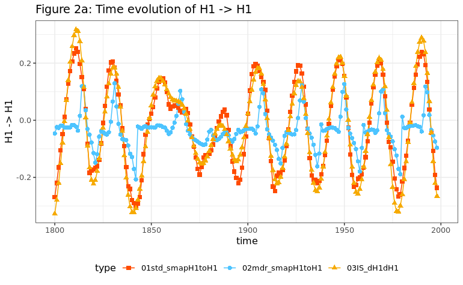

```r
fig2a_ggplot <- ggplot(data = H2P2_H1toH1_ggplot) +
  scale_colour_manual(values = c("#ff4b00", "#4dc4ff", "#f6aa00")) +
  scale_shape_manual(values = c(15, 16, 17)) +
　geom_line(aes(x = time, y = IntS, group = type, color = type)) +
  geom_point(aes(x = time, y = IntS, color = type, shape = type), size = 2) +
  xlim(1800, 1999) + theme_bw() + theme(legend.position = "bottom") +
  labs(title = "Figure 2a: Time evolution of H1 -> H1", x = "time", y = "H1 -> H1")

fig2b_ggplot <- ggplot(H2P2_error_H1toH1_ggplot, aes(type, abs(IntS))) +
    scale_colour_manual(values = c("#ff4b00", "#4dc4ff", "#f6aa00")) +
    scale_shape_manual(values = c(15, 16, 17)) +
    geom_boxplot(outlier.shape = NA) +
    geom_jitter(aes(shape = type, color = type, alpha = 0.1), width = 0.25, size = 3) +
    theme_bw() + theme(legend.position = "bottom") +
    labs (title = "Figure 2b: Comparison to parametric IS: H1 -> H1")

plot(fig2a_ggplot)
ggsave("fig2a.pdf", width = 6, height = 4)
```

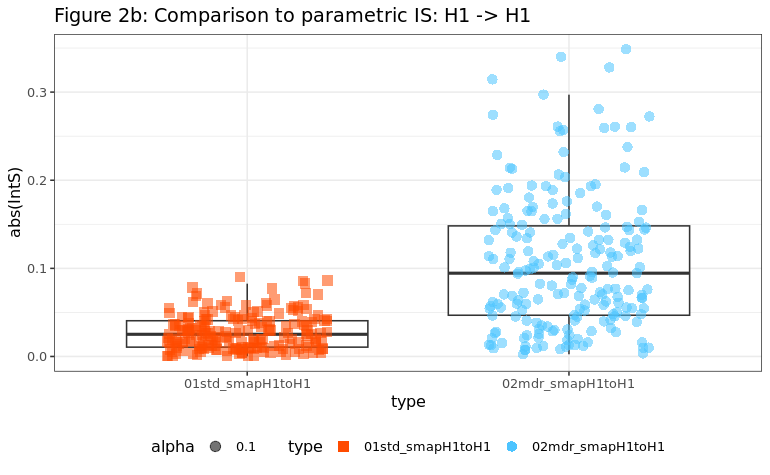

```r
plot(fig2b_ggplot)
ggsave("fig2b.pdf", width = 4, height = 4)
```

##### [4.6.4] Comparison for the off-diagonal element (Fig. 2cd: P1 -> H1): ggplot

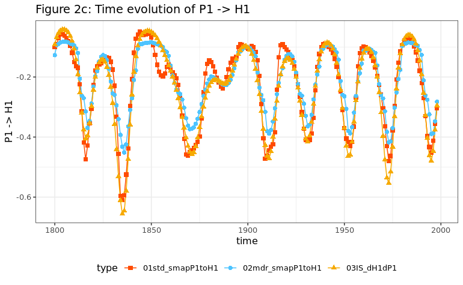

```r
fig2c_ggplot <- ggplot(data = H2P2_P1toH1_ggplot) +
  scale_colour_manual(values = c("#ff4b00", "#4dc4ff", "#f6aa00")) +
  scale_shape_manual(values = c(15, 16, 17)) +
　geom_line(aes(x = time, y = IntS, group = type, color = type)) +
  geom_point(aes(x = time, y = IntS, color = type, shape = type), size = 2) +
  xlim(1800, 1999) + theme_bw() + theme(legend.position = "bottom") +
  labs(title = "Figure 2c: Time evolution of P1 -> H1", x = "time", y = "P1 -> H1")

fig2d_ggplot <- ggplot(H2P2_error_P1toH1_ggplot, aes(type, abs(IntS))) +
    scale_colour_manual(values = c("#ff4b00", "#4dc4ff", "#f6aa00")) +
    scale_shape_manual(values = c(15, 16, 17)) +
    geom_boxplot(outlier.shape = NA) +
    geom_jitter(aes(shape = type, color = type, alpha = 0.1), width = 0.25, size = 3) +
    theme_bw() + theme(legend.position = "bottom") +
    labs (title = "Figure 2d: Comparison to parametric IS: P1 -> H1")

plot(fig2c_ggplot)
ggsave("fig2c.pdf", width = 6, height = 4)
```

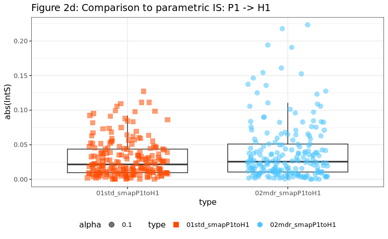

```r
plot(fig2d_ggplot)
ggsave("fig2d.pdf", width = 4, height = 4)
```

##### [4.6.5] Comparison for both diagonal and off-diagonal by correlation/regression

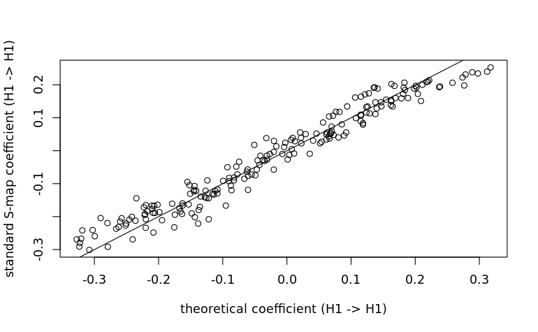

```r
#for diagonal element (H1 -> H1)
plot(dF_H1dH1(HP_result)[-final_ID], HP_m_smap_res2_s$smap_coefficients[[1]]$c_1[-final_ID] - delta_11,
     xlab = "theoretical coefficient (H1 -> H1)",
     ylab = "standard S-map coefficient (H1 -> H1)",
     )
abline(coef = c(0,1))
```

```r
cor(dF_H1dH1(HP_result)[-final_ID], HP_m_smap_res2_s$smap_coefficients[[1]]$c_1[-final_ID] - delta_11)
```

```
[1] 0.9781177
```

```r
#Y should be the theoretical coefficient
x <- HP_m_smap_res2_s$smap_coefficients[[1]]$c_1[-final_ID] - delta_11
summary(lm(dF_H1dH1(HP_result)[-final_ID] ~ x))
```

```
Call:
lm(formula = dF_H1dH1(HP_result)[-final_ID] ~ x)

Residuals:
      Min        1Q    Median        3Q       Max
-0.082187 -0.024128  0.001541  0.023675  0.097218

Coefficients:
             Estimate Std. Error t value Pr(>|t|)
(Intercept) -0.001131   0.002422  -0.467    0.641
x            1.047491   0.015874  65.986   <2e-16 ***
---
Signif. codes:  0 ‘***’ 0.001 ‘**’ 0.01 ‘*’ 0.05 ‘.’ 0.1 ‘ ’ 1

Residual standard error: 0.03386 on 197 degrees of freedom
Multiple R-squared:  0.9567,    Adjusted R-squared:  0.9565
F-statistic:  4354 on 1 and 197 DF,  p-value: < 2.2e-16
```

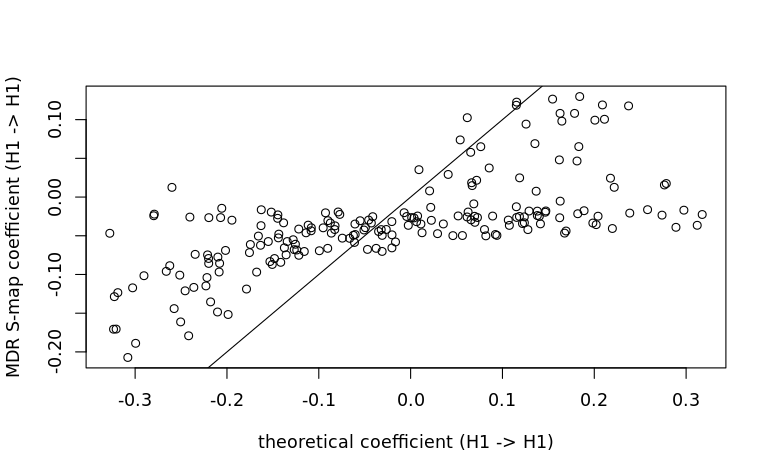

```r
plot(dF_H1dH1(HP_result)[-final_ID], MDR_Smap_dH1dH1,
     xlab = "theoretical coefficient (H1 -> H1)",
     ylab = "MDR S-map coefficient (H1 -> H1)"
     )
abline(coef = c(0,1))
```

```r
cor(dF_H1dH1(HP_result)[-final_ID], MDR_Smap_dH1dH1)
```

```
[1] 0.6705204
```

```r
summary(lm(dF_H1dH1(HP_result)[-final_ID] ~ MDR_Smap_dH1dH1))
```

```
Call:
lm(formula = dF_H1dH1(HP_result)[-final_ID] ~ MDR_Smap_dH1dH1)

Residuals:
     Min       1Q   Median       3Q      Max
-0.32306 -0.07849 -0.01325  0.07168  0.33871

Coefficients:
                Estimate Std. Error t value Pr(>|t|)
(Intercept)     0.040208   0.009882   4.069 6.83e-05 ***
MDR_Smap_dH1dH1 1.832602   0.144465  12.685  < 2e-16 ***
---
Signif. codes:  0 ‘***’ 0.001 ‘**’ 0.01 ‘*’ 0.05 ‘.’ 0.1 ‘ ’ 1

Residual standard error: 0.1208 on 197 degrees of freedom
Multiple R-squared:  0.4496,    Adjusted R-squared:  0.4468
F-statistic: 160.9 on 1 and 197 DF,  p-value: < 2.2e-16
```

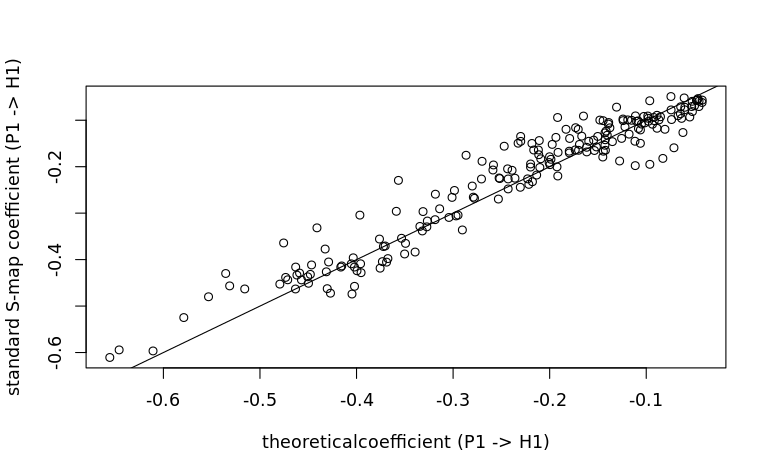

```r
#for off-diagonal element (P1 -> H1)
plot(dF_H1dP1(HP_result)[-final_ID] * HP_result.sd[3] / HP_result.sd[1], HP_m_smap_res2_s$smap_coefficients[[1]]$c_3[-final_ID],
     xlab = "theoreticalcoefficient (P1 -> H1)",
     ylab = "standard S-map coefficient (P1 -> H1)"
     )
abline(coef = c(0,1))
```

```r
cor(dF_H1dP1(HP_result)[-final_ID] * HP_result.sd[3] / HP_result.sd[1], HP_m_smap_res2_s$smap_coefficients[[1]]$c_3[-final_ID])
```

```
[1] 0.9619422
```

```r
y <- dF_H1dP1(HP_result)[-final_ID] * HP_result.sd[3] / HP_result.sd[1]
summary(lm(y ~ HP_m_smap_res2_s$smap_coefficients[[1]]$c_3[-final_ID]))
```

```
Call:
lm(formula = y ~ HP_m_smap_res2_s$smap_coefficients[[1]]$c_3[-final_ID])

Residuals:
      Min        1Q    Median        3Q       Max
-0.116567 -0.021643  0.001839  0.021454  0.109281

Coefficients:
                                                        Estimate Std. Error
(Intercept)                                            -0.007259   0.005382
HP_m_smap_res2_s$smap_coefficients[[1]]$c_3[-final_ID]  1.014493   0.020532
                                                       t value Pr(>|t|)
(Intercept)                                             -1.349    0.179
HP_m_smap_res2_s$smap_coefficients[[1]]$c_3[-final_ID]  49.410   <2e-16 ***
---
Signif. codes:  0 ‘***’ 0.001 ‘**’ 0.01 ‘*’ 0.05 ‘.’ 0.1 ‘ ’ 1

Residual standard error: 0.03924 on 197 degrees of freedom
Multiple R-squared:  0.9253,    Adjusted R-squared:  0.925
F-statistic:  2441 on 1 and 197 DF,  p-value: < 2.2e-16
```

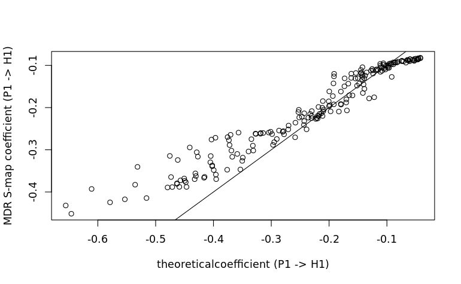

```r
plot(dF_H1dP1(HP_result)[-final_ID] * HP_result.sd[3] / HP_result.sd[1], MDR_Smap_dH1dP1,
     xlab = "theoreticalcoefficient (P1 -> H1)",
     ylab = "MDR S-map coefficient (P1 -> H1)"
     )
abline(coef = c(0,1))
```

```r
cor(MDR_Smap_dH1dP1, dF_H1dP1(HP_result)[-final_ID] * HP_result.sd[3] / HP_result.sd[1])
```

```
[1] 0.9709203
```

```r
summary(lm(y ~ MDR_Smap_dH1dP1))
```

```
Call:
lm(formula = y ~ MDR_Smap_dH1dP1)

Residuals:
      Min        1Q    Median        3Q       Max
-0.122178 -0.017208  0.004087  0.022169  0.071996

Coefficients:
                Estimate Std. Error t value Pr(>|t|)
(Intercept)     0.049246   0.005555   8.864  4.6e-16 ***
MDR_Smap_dH1dP1 1.368911   0.024048  56.923  < 2e-16 ***
---
Signif. codes:  0 ‘***’ 0.001 ‘**’ 0.01 ‘*’ 0.05 ‘.’ 0.1 ‘ ’ 1

Residual standard error: 0.03438 on 197 degrees of freedom
Multiple R-squared:  0.9427,    Adjusted R-squared:  0.9424
F-statistic:  3240 on 1 and 197 DF,  p-value: < 2.2e-16
```

### [5] Model02 setting

#### [5.1] Model equations for the 5-species coupled food chain ODE model

$$\frac{dP_i}{dt} = v_i \lambda_i \frac{P_i C_i}{C_i + C_i^*} - v_i P_i,
\quad (i=1,2) \tag{1}$$

$$\frac{dC_i}{dt} = \mu_i \kappa_i \frac{C_i R}{R + R^*} - v_i \lambda_i
\frac{P_i C_i}{C_i + C_i^*} - \mu_i C_i, \quad (i=1,2) \tag{2}$$

$$\frac{dR}{dt} = R \left( 1 - \frac{R}{k} \right) - \sum_{i=1,2} \mu_i
\kappa_i \frac{C_iR}{R + R^*}.\tag{3}$$

#### [5.2] Parameters and settings for the 5-species coupled food chain ODE model

##### [5.2.1] Parameter value setting

```r
v1 = 0.1
v2 = 0.07
lambd1 = 3.2
lambd2 = 2.9
Cstar1 = 0.5
Cstar2 = 0.5
myu1 = 0.15
myu2 = 0.15
kp1 = 2.5
kp2 = 2.0
Rstar = 0.3
k = 1.2
```

##### [5.2.2] Settings for numerically solving ODEs

```r
j_P1 <- 1
j_P2 <- 2
j_C1 <- 3
j_C2 <- 4
j_R <- 5
```

##### [5.2.3] Functions specific to the 5-sp model

```r
dP1dt <- function(in_vec, t)
{
  growth <- v1 * lambd1 * in_vec[j_P1] * in_vec[j_C1] / (in_vec[j_C1] + Cstar1)
  mortality <- v1 * in_vec[j_P1]
  return(growth - mortality)
}

dP2dt <- function(in_vec, t)
{
  growth <- v2 * lambd2 * in_vec[j_P2] * in_vec[j_C2] / (in_vec[j_C2] + Cstar2)
  mortality <- v2 * in_vec[j_P2]
  return(growth - mortality)
}

dC1dt <- function(in_vec, t)
{
  growth <- myu1 * kp1 * in_vec[j_C1] * in_vec[j_R] / (in_vec[j_R] + Rstar)
  mortality <- v1 * lambd1 * in_vec[j_P1] * in_vec[j_C1] / (in_vec[j_C1] + Cstar1) + myu1 * in_vec[j_C1]
  return(growth - mortality)
}

dC2dt <- function(in_vec, t)
{
  growth <- myu2 * kp2 * in_vec[j_C2] * in_vec[j_R] / (in_vec[j_R] + Rstar)
  mortality  <- v2 * lambd2 * in_vec[j_P2] * in_vec[j_C2] / (in_vec[j_C2] + Cstar2) + myu2 * in_vec[j_C2]
  return(growth - mortality)
}

dRdt <- function(in_vec, t)
{
  growth <- in_vec[j_R] * (1.0 - in_vec[j_R] / k)
  mortality <- myu1 * kp1 * in_vec[j_C1] * in_vec[j_R] / (in_vec[j_R] + Rstar) + myu2 * kp2 * in_vec[j_C2] * in_vec[j_R] / (in_vec[j_R] + Rstar)
  return(growth - mortality)
}

#function to calculate all coefficients, five dimensional
diff_5sp <- function(in_vec, ref_data, t, h_interval, dim){
  temp_vec <- numeric(dim)
  temp_vec[j_P1] <- dP1dt(in_vec, t)
  temp_vec[j_P2] <- dP2dt(in_vec, t)
  temp_vec[j_C1] <- dC1dt(in_vec, t)
  temp_vec[j_C2] <- dC2dt(in_vec, t)
  temp_vec[j_R] <- dRdt(in_vec, t)
  temp_vec
}
```

##### [5.2.4] Initial setting and conditions

```r
dim_model1 <- 5
nv0 <- numeric(dim_model1)
nv <- numeric(dim_model1)

nv0[j_R] <- 1.0
nv0[j_C1] <- 0.5
nv0[j_C2] <- 0.8
nv0[j_P1] <- 0.7
nv0[j_P2] <- 0.8

deltat <- 0.01
```

#### [5.3] Solving the model

##### [5.3.1] Solving the model by the RK4 method

```r
t <- 0.0  # initial condition (initial time, 0)
end_time <- 2000; tau <- 5; transient_period <- 1000
write_index <- 1

#Initial condition set
nv <- nv0

#write initial condition
cat(t, nv, "\n")
```

```
0 0.7 0.8 0.5 0.8 1
```

```r
#For the transient dynamics (RUN BURN)
for(i in 1:as.integer(transient_period / deltat)){
  nv <- rk4(in_vec = nv, time = t, h_interval = deltat, dim = dim_model1, diff_vec = diff_5sp)
  t <- t + deltat # update time
}

# record the initial condition after BURNING phase
rk4_result <- data.frame(t = t, P1 = nv[j_P1], P2 = nv[j_P2], C1 = nv[j_C1], C2 = nv[j_C2], R = nv[j_R])

#After transient period
for(i in 1:as.integer((end_time - transient_period) / deltat)){
  nv <- rk4(in_vec = nv, time = t, h_interval = deltat, dim = dim_model1, diff_vec = diff_5sp)
  t <- t + deltat # update time
  ###recored the result every "tau only
  if(write_index < as.integer(tau / deltat)){
    write_index <- write_index + 1
  }
  else {
    #cat(time, nv_ee1,"\n")
    rk4_result <- rbind.data.frame(rk4_result, c(t, nv[j_P1], nv[j_P2], nv[j_C1], nv[j_C2], nv[j_R]))
    write_index <- 1
  }
}
head(rk4_result)
```

|  | t | P1 | P2 | C1 | C2 | R |
| --- | --- | --- | --- | --- | --- | --- |
| 1 | 1000 | 0.02859502 | 0.0006634802 | 0.5832081 | 8.398886e-05 | 1.02549882 |
| 2 | 1005 | 0.04644283 | 0.0004676444 | 1.0952224 | 1.237957e-04 | 0.84571190 |
| 3 | 1010 | 0.09194131 | 0.0003296405 | 1.7706399 | 1.632301e-04 | 0.43551918 |
| 4 | 1015 | 0.19295176 | 0.0002323665 | 1.3899544 | 1.252858e-04 | 0.02259743 |
| 5 | 1020 | 0.32249783 | 0.0001637760 | 0.5151302 | 6.258489e-05 | 0.01354191 |
| 6 | 1025 | 0.35154791 | 0.0001154221 | 0.1708874 | 3.928910e-05 | 0.28854989 |

```r
saveRDS(rk4_result, "rk4_result_5sp_model.obj")
```

##### [5.3.2] Basic plot for the result

```r
plot(rk4_result$t, rk4_result$C1, col = "red", type = "l", xlab = "time", ylab = "abundance", ylim = c(0, 2.0))
par(new = T)
```

```r
plot(rk4_result$t, rk4_result$C2, col = "blue", type = "l", xlab = "", ylab = "", ylim = c(0, 2.0))
par(new = T)
```

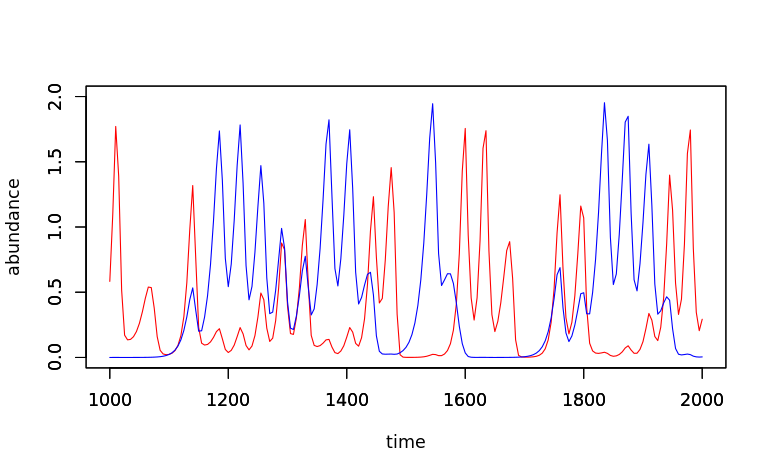

```r
plot(rk4_result$t, rk4_result$R, col = "green", type = "l", xlab = "", ylab = "", ylim = c(0, 2.0))
```

### [6] Theoretical coefficients evaluated by instantaneous Jacobian

The partial derivative of dC1/dt

with respect to C1:
$$\frac{\partial}{\partial C_{1}} \left( \mu_{1} K_{1} \frac{C_{1} R}{R +
R^{*}} - v_{1} \lambda_{1} \frac{P_{1} C_{1}}{C_{1} + C_{1}^{*}} -
\mu_{1} C_{1} \right) = K_{1} \mu_{1} \frac{R}{R + R^{*}} - v_{1}
\lambda_{1} \frac{P_{1} C_{1}*}{(C_{1} + C_{1}^{*})^2} - \mu_{1}$$

with respect to R:
$$\frac{\partial}{\partial R} \left( \mu_{1} \kappa_{1} \frac{C_{1} R}{R +
R^{*}} \right) = \kappa_{1} \mu_{1} \frac{C_{1} R^*}{(R + R^{*})^2}$$

Function definition

```r
dC1dC1 <- function(data) {
  coeff <- myu1 * kp1 * data$R / (data$R + Rstar) - v1 * lambd1 * data$P1 * Cstar1/ (data$C1 + Cstar1)^2 - myu1
  return(coeff)
}
dC1dR <- function(data) {
  coeff <- myu1 * kp1 * data$C1 *Rstar / (data$R + Rstar)^2
  return(coeff)
}
```

### [7] Adjusted interaction strengths with multivariate S-map

```r
rk4_result.mean <- apply(rk4_result[, -1], 2, mean, na.rm = T)  # mean abundance
rk4_result.sd <- apply(rk4_result[, -1], 2, sd, na.rm = T)      # SD of abundance

mean_mat <- matrix(rk4_result.mean, nrow = nrow(rk4_result) , ncol = length(rk4_result.mean), byrow = TRUE)
sd_mat <- matrix(rk4_result.sd, nrow = nrow(rk4_result) , ncol = length(rk4_result.mean), byrow = TRUE)

rk4_result_s <- (rk4_result[, -1] - mean_mat) /sd_mat # Standardized dataset
head(rk4_result_s)
```

|  | P1 | P2 | C1 | C2 | R |
| --- | --- | --- | --- | --- | --- |
| 1 | -0.5350630 | -0.4891857 | 0.5052931 | -0.9263704 | 0.8686688 |
| 2 | -0.4571503 | -0.4905663 | 1.7093636 | -0.9262944 | 0.4445209 |
| 3 | -0.2585317 | -0.4915393 | 3.2976987 | -0.9262192 | -0.5231935 |
| 4 | 0.1824184 | -0.4922251 | 2.4024655 | -0.9262916 | -1.4973462 |
| 5 | 0.7479376 | -0.4927086 | 0.3451987 | -0.9264112 | -1.5187097 |
| 6 | 0.8747525 | -0.4930495 | -0.4643346 | -0.9264556 | -0.8699191 |

##### [7.1.2] Analaysis with the standardized time series data

```r
# data block for smap
rk4_smap_block_s <- data.frame(P1 = rk4_result_s$P1, P2 = rk4_result_s$P2, C1 = rk4_result_s$C1, C2 = rk4_result_s$C2, R = rk4_result_s$R)

# delete a few column
#rk4_smap_block_s <- rk4_smap_block_s[, -j_P2] #delete P2 from the embedding

# conducting smap for obtaining the optimal theta
rk4_m_smap_res_s <- block_lnlp(rk4_smap_block_s, method = "s-map",
                         target_column = j_C1,
                         theta = c(0, 1e-04, 3e-04, 0.001, 0.003, 0.01, 0.03, 0.1, 0.3, 0.5, 0.75, 1, 1.5, 2, 3, 4, 6, 8),
                         silent = TRUE)
```

Plotting the effect of theta

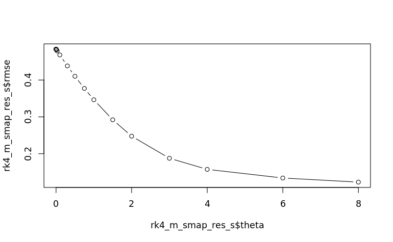

```r
plot(rk4_m_smap_res_s$theta, rk4_m_smap_res_s$rmse, type = "b")
```

```r
(rk4_opt_theta_s <- rk4_m_smap_res_s$theta[which.min(rk4_m_smap_res_s$rmse)])
```

```
[1] 8
```

Conducting standard smap with the optimal theta

```r
rk4_m_smap_res2_s <- block_lnlp(rk4_smap_block_s, method = "s-map",
                              target_column = j_C1,
                              theta = rk4_opt_theta_s,
                              silent = TRUE,
                              save_smap_coefficients = TRUE)
head(as.data.frame(rk4_m_smap_res2_s$smap_coefficients[[1]]))
```

|  | c_1 | c_2 | c_3 | c_4 | c_5 | c_0 |
| --- | --- | --- | --- | --- | --- | --- |
| 1 | -0.5734469 | 0.14998720 | 1.6523454 | 0.01567876 | 0.1719974 | 0.35529942 |
| 2 | -0.6933974 | 0.63277456 | 1.2759629 | 0.58625658 | 1.5399624 | 0.27210463 |
| 3 | -0.4551806 | -0.03557514 | 0.5980752 | -0.27775446 | 1.7756718 | 1.25420409 |
| 4 | -0.3887902 | 0.12103751 | 0.3998455 | -0.25313686 | 1.5155411 | 1.57640180 |
| 5 | -0.1274927 | 0.23676704 | 0.2526806 | -0.04526734 | 0.2444098 | 0.01654777 |
| 6 | -0.1390863 | 0.15455882 | 0.1663467 | -0.16193391 | 0.1560928 | -0.20361283 |

#### [7.2] Compare standard S-map and instantaneous interaction strengths (IIS)

```r
final_ID <- 201
plot(rk4_result$t[-final_ID], rk4_m_smap_res2_s$smap_coefficients[[1]]$c_3[-final_ID] - 1.0, type = "l", col = 1, ylim = c(-1, 1), xlab = "time", ylab = "Smap coefficient: C1 -> C1")
par(new = T)
```

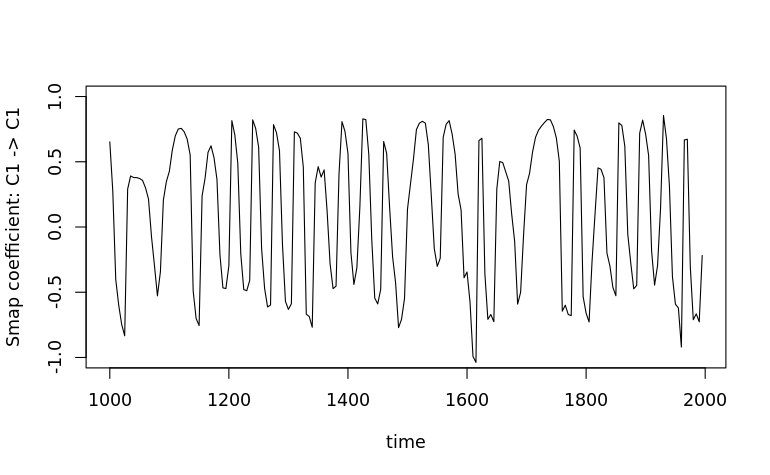

```r
plot(rk4_result$t[-final_ID], tau*dC1dC1(rk4_result)[-final_ID], type = "l", col = "blue", ylim = c(-1, 1), xlab = "", ylab = "")
```

### [8] Deriving mathematically correct interaction coefficients

#### [8.1] Model setting

##### [8.1.1] List of partial derivatives (Jacobian)

$$\frac{\partial F_{P_1}}{\partial P_1} = v_1 \lambda_1 \frac{C_1}{C_1 +
C_1^*} - v_1,
\frac{\partial F_{P_1}}{\partial P_2} = 0,
\frac{\partial F_{P_1}}{\partial C_1} = v_1 \lambda_1 \frac{P_1
C_1^*}{(C_1 + C_1^*)^2},
\frac{\partial F_{P_1}}{\partial C_2} = \frac{\partial F_{P_1}}{\partial
R} = 0,$$

$$\frac{\partial F_{P_2}}{\partial P_1} = 0,
\frac{\partial F_{P_2}}{\partial P_2} = v_2 \lambda_2 \frac{C_2}{C_2 +
C_2^*} - v_2,
\frac{\partial F_{P_2}}{\partial C_1} = 0,
\frac{\partial F_{P_2}}{\partial C_2} = v_2 \lambda_2 \frac{P_2
C_2^*}{(C_2 + C_2^*)^2},
\frac{\partial F_{P_2}}{\partial R} = 0,$$

$$\frac{\partial F_{C_1}}{\partial P_1} = -v_1 \lambda_1 \frac{C_1}{C_1 +
C_1^*},
\frac{\partial F_{C_1}}{\partial P_2} = 0,
\frac{\partial F_{C_1}}{\partial C_1} = \mu_1 \kappa_1 \frac{R}{R + R^*}
- v_1 \lambda_1 \frac{P_1 C_1^*}{(C_1 + C_1^*)^2} - \mu_1,
\frac{\partial F_{C_1}}{\partial C_2} = 0,
\frac{\partial F_{C_1}}{\partial R} = \mu_1 \kappa_1 \frac{C_1 R^*}{(R +
R^*)^2},$$

$$\frac{\partial F_{C_2}}{\partial P_1} = 0,
\frac{\partial F_{C_2}}{\partial P_2} = -v_2 \lambda_2 \frac{C_2}{C_2 +
C_2^*},
\frac{\partial F_{C_2}}{\partial C_1} = 0,
\frac{\partial F_{C_2}}{\partial C_2} = \mu_2 \kappa_2 \frac{R}{R + R^*}
- v_2 \lambda_2 \frac{P_2 C_2^*}{(C_2 + C_2^*)^2} - \mu_2,
\frac{\partial F_{C_2}}{\partial R} = \mu_2 \kappa_2 \frac{C_2 R^*}{(R +
R^*)^2},$$

$$\frac{\partial F_{R}}{\partial P_1} = \frac{\partial F_{R}}{\partial
P_2} = 0,
\frac{\partial F_{R}}{\partial C_1} = - \mu_1 \kappa_1 \frac{R}{R +
R^*},
\frac{\partial F_{R}}{\partial C_2} = - \mu_2 \kappa_2 \frac{R}{R +
R^*},
\frac{\partial F_{R}}{\partial R} = \left( 1 - \frac{2 R}{k} \right)-
\sum_{i=1,2} \mu_i \kappa_i \frac{C_i R^*}{(R + R^*)^2}.$$

##### [8.1.2] Functions specific to the linearized model

Partial derivatives

```r
rF_P1rX <- function(in_vec, t) {
  nv_p <- numeric(length(in_vec))

  nv_p[j_P1] <- v1 * lambd1 * in_vec[j_C1] / (in_vec[j_C1] + Cstar1) - v1
  nv_p[j_P2] <- 0
  nv_p[j_C1] <- v1 * lambd1 * in_vec[j_P1] * Cstar1 / (in_vec[j_C1] + Cstar1)^2
  nv_p[j_C2] <- 0
  nv_p[j_R] <- 0

  return(nv_p)
}

rF_P2rX <- function(in_vec, t) {
  nv_p <- numeric(length(in_vec))

  nv_p[j_P2] <- v2 * lambd2 * in_vec[j_C2] / (in_vec[j_C2] + Cstar2) - v2
  nv_p[j_P1] <- 0
  nv_p[j_C2] <- v2 * lambd2 * in_vec[j_P2] * Cstar2 / (in_vec[j_C2] + Cstar2)^2
  nv_p[j_C1] <- 0
  nv_p[j_R] <- 0

  return(nv_p)
}

rF_C1rX <- function(in_vec, t) {
  nv_p <- numeric(length(in_vec))

  nv_p[j_P1] <- -v1 * lambd1 * in_vec[j_C1] / (in_vec[j_C1] + Cstar1)
  nv_p[j_P2] <- 0
  nv_p[j_C1] <- myu1 * kp1 * in_vec[j_R] / (in_vec[j_R] + Rstar) - v1 * lambd1 * in_vec[j_P1] * Cstar1/ (in_vec[j_C1] + Cstar1)^2 - myu1
  nv_p[j_C2] <- 0
  nv_p[j_R] <- myu1 * kp1 * in_vec[j_C1] * Rstar / (in_vec[j_R] + Rstar)^2

  return(nv_p)
}

rF_C2rX <- function(in_vec, t) {
  nv_p <- numeric(length(in_vec))

  nv_p[j_P2] <- -v2 * lambd2 * in_vec[j_C2] / (in_vec[j_C2] + Cstar2)
  nv_p[j_P1] <- 0
  nv_p[j_C2] <- myu2 * kp2 * in_vec[j_R] / (in_vec[j_R] + Rstar) - v2 * lambd2 * in_vec[j_P2] * Cstar2/ (in_vec[j_C2] + Cstar2)^2 - myu2
  nv_p[j_C1] <- 0
  nv_p[j_R] <- myu2 * kp2 * in_vec[j_C2] * Rstar / (in_vec[j_R] + Rstar)^2

  return(nv_p)
}

rF_RrX <- function(in_vec, t) {
  nv_p <- numeric(length(in_vec))

  nv_p[j_P1] <- 0
  nv_p[j_P1] <- 0
  nv_p[j_C1] <- -myu1 * kp1 * in_vec[j_R] / (in_vec[j_R] + Rstar)
  nv_p[j_C2] <- -myu2 * kp2 * in_vec[j_R] / (in_vec[j_R] + Rstar)
  nv_p[j_R] <- (1 - 2 * in_vec[j_R] / k) - (myu1 * kp1 * in_vec[j_C1] + myu2 * kp2 * in_vec[j_C2]) * Rstar / (in_vec[j_R] + Rstar)^2

  return(nv_p)
}
```

Linearlized perturbed ODE system equations
$$\frac{d\boldsymbol{\delta}(t)}{dt} = \mathbf{J}_{t}
\boldsymbol{\delta}(t), \quad \boldsymbol{\delta}(0) = \Delta
\boldsymbol{x}_{j}. \tag{7a}$$

$$\begin{align}
IC_{i,j,adj}(k=k_1) &= \lim_{\Delta x \to 0}
\frac{\left[\phi(\boldsymbol{x}(k_1) + \Delta x_j, \tau) -
\phi(\boldsymbol{x}(k_1), \tau)\right]_i}{\Delta x} - \delta_{ij}\\
&= \lim_{\Delta x \to 0} \frac{\left[\boldsymbol{\delta}_n
(\tau)\right]_i}{\Delta x} - \delta_{ij} \\
&\approx \frac{\left[\boldsymbol{\delta}_n (\tau)\right]_i}{\Delta
x} - \delta_{ij} \tag{7c}
\end{align}$$

Linearlized ODE system

```r
dP1Ldt <- function(in_vec, ref_data, t)
{
  ref_vec <- as.numeric(ref_data[t, -1])
  return(as.numeric(rF_P1rX(ref_vec) %*% in_vec))
}

dP2Ldt <- function(in_vec, ref_data, t)
{
  ref_vec <- as.numeric(ref_data[t, -1])
  return(as.numeric(rF_P2rX(ref_vec) %*% in_vec))
}

dC1Ldt <- function(in_vec, ref_data, t)
{
  ref_vec <- as.numeric(ref_data[t, -1])
  return(as.numeric(rF_C1rX(ref_vec) %*% in_vec))
}

dC2Ldt <- function(in_vec, ref_data, t)
{
  ref_vec <- as.numeric(ref_data[t, -1])
  return(as.numeric(rF_C2rX(ref_vec) %*% in_vec))
}

dRLdt <- function(in_vec, ref_data, t)
{
  ref_vec <- as.numeric(ref_data[t, -1])
  return(as.numeric(rF_RrX(ref_vec) %*% in_vec))
}


#function to calculate all coefficients, five dimensional
diff_L_5sp <- function(in_vec, ref_data, t, h_interval, dim){
  temp_vec <- numeric(dim)

  t_index <- as.integer((t / h_interval) * 2) #to convert continuous time to the number of row

  temp_vec[j_P1] <- dP1Ldt(in_vec, ref_data, t_index)
  temp_vec[j_P2] <- dP2Ldt(in_vec, ref_data, t_index)
  temp_vec[j_C1] <- dC1Ldt(in_vec, ref_data, t_index)
  temp_vec[j_C2] <- dC2Ldt(in_vec, ref_data, t_index)
  temp_vec[j_R] <- dRLdt(in_vec, ref_data, t_index)
  temp_vec
}
```

#### [8.2] Solving the model

##### [8.2.1] Preparing the fine solution of the ODEs without perturbation

Since rk4() includes the evaluation of derivatives at t + deltat/2, we need to have numerical solutions with the high resolution with deltat/2

```r
t <- 0.0  # initial condition (initial time, 0)
end_time <- 2000; tau <- 5; transient_period <- 1000
write_index <- 1
deltat_fine <- deltat * 0.5

#Initial condition set
nv_rk4_fine <- nv0

# write initial condition
cat(t, nv_rk4_fine, "\n")
```

```
0 0.7 0.8 0.5 0.8 1
```

```r
#For the transient dynamics (RUN BURN)
for(i in 1:as.integer(transient_period / deltat_fine)){
  nv_rk4_fine <- rk4(in_vec = nv_rk4_fine, time = t, h_interval = deltat_fine, dim = dim_model1, diff_vec = diff_5sp)
  t <- t + deltat_fine # update time
}

# record the initial condition after BURNING period
rk4_result_fine <- data.frame(t = t, P1 = nv_rk4_fine[j_P1], P2 = nv_rk4_fine[j_P2], C1 = nv_rk4_fine[j_C1], C2 = nv_rk4_fine[j_C2], R = nv_rk4_fine[j_R])

#After transient period
for(i in 1:as.integer((end_time - transient_period) / deltat_fine)){
  nv_rk4_fine <- rk4(in_vec = nv_rk4_fine, time = t, h_interval = deltat_fine, dim = dim_model1, diff_vec = diff_5sp)
  t <- t + deltat_fine # update time
  rk4_result_fine <- rbind.data.frame(rk4_result_fine, c(t, nv_rk4_fine[j_P1], nv_rk4_fine[j_P2], nv_rk4_fine[j_C1], nv_rk4_fine[j_C2], nv_rk4_fine[j_R]))
}

head(rk4_result_fine)
```

|  | t | P1 | P2 | C1 | C2 | R |
| --- | --- | --- | --- | --- | --- | --- |
| 1 | 1000.000 | 0.02859502 | 0.0006634802 | 0.5832081 | 8.398886e-05 | 1.025499 |
| 2 | 1000.005 | 0.02860536 | 0.0006632481 | 0.5835922 | 8.402323e-05 | 1.025398 |
| 3 | 1000.010 | 0.02861571 | 0.0006630161 | 0.5839766 | 8.405762e-05 | 1.025297 |
| 4 | 1000.015 | 0.02862607 | 0.0006627842 | 0.5843611 | 8.409201e-05 | 1.025197 |
| 5 | 1000.020 | 0.02863645 | 0.0006625524 | 0.5847459 | 8.412642e-05 | 1.025095 |
| 6 | 1000.025 | 0.02864683 | 0.0006623206 | 0.5851310 | 8.416084e-05 | 1.024994 |

```r
#saveRDS(rk4_result_fine, paste("default", "_rk4_result_fine.obj", sep=""))
#saveRDS(rk4_result_fine, paste(Sys.Date(), "_rk4_result_fine.obj", sep=""))
```

Comparing the solution

```r
plot(rk4_result$t, rk4_result$C1, col = "red", type = "l", xlab = "time", ylab = "abundance", ylim = c(0, 2.0))
par(new = T)
```

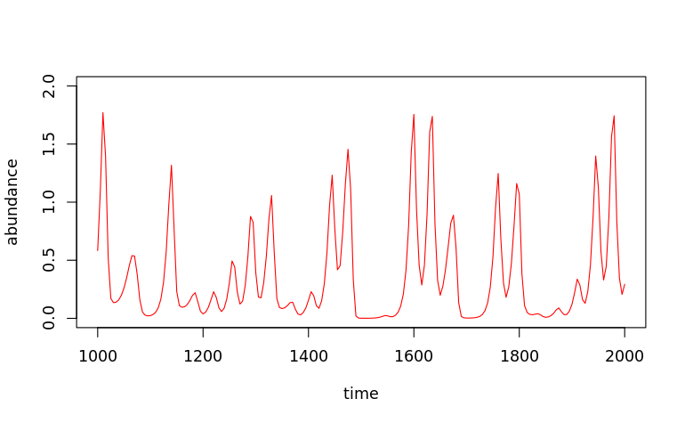

```r
plot(rk4_result_fine$t, rk4_result_fine$C1, col = "black", type = "l", xlab = "", ylab = "", ylim = c(0, 2.0), lty = "dashed")
```

##### [8.2.2] Trial for the linearized ODEs for a short time period

```r
#loading the default
rk4_result_fine <- readRDS("default_rk4_result_fine.obj")

delta_x = 0.01 #size of a small perturbation
t <- deltat / 2  # initial condition (initial time, t_abs = transient_period)
t_abs <- t + transient_period - deltat / 2
end_time <- 1.0; tau <- 5;
write_index <- 1

#Initial condition
nv_linear_p <- c(0, 0, delta_x, 0, 0)
# record the initial condition
result_linear_p <- data.frame(t = t_abs, P1 = nv_linear_p[j_P1], P2 = nv_linear_p[j_P2], C1 = nv_linear_p[j_C1], C2 = nv_linear_p[j_C2], R = nv_linear_p[j_R])

for(i in 1:as.integer(end_time / deltat)){
  nv_linear_p <- rk4(in_vec = nv_linear_p, ref_data = rk4_result_fine, time = t, h_interval = deltat, dim = dim_model1, diff_vec = diff_L_5sp)
  t <- t + deltat # update time (starting from the middle)
  t_abs <- t_abs + deltat
  result_linear_p <- rbind.data.frame(result_linear_p, c(t_abs, nv_linear_p[j_P1], nv_linear_p[j_P2], nv_linear_p[j_C1], nv_linear_p[j_C2], nv_linear_p[j_R]))
}
 result_linear_p
```

| t | P1 | P2 | C1 | C2 | R |
| --- | --- | --- | --- | --- | --- |
| 1000.00 | 0.000000e+00 | 0.000000e+00 | 0.01000000 | 0.000000e+00 | 0.000000e+00 |
| 1000.01 | 3.902010e-07 | -5.593843e-19 | 0.01001363 | -6.234720e-13 | -2.892371e-05 |
| 1000.02 | 7.809452e-07 | -4.468521e-18 | 0.01002726 | -2.491342e-12 | -5.767056e-05 |
| 1000.03 | 1.172233e-06 | -1.505920e-17 | 0.01004090 | -5.599823e-12 | -8.624204e-05 |
| 1000.04 | 1.564067e-06 | -3.564376e-17 | 0.01005454 | -9.945173e-12 | -1.146396e-04 |
| 1000.05 | 1.956446e-06 | -6.951528e-17 | 0.01006819 | -1.552369e-11 | -1.428648e-04 |
| 1000.06 | 2.349373e-06 | -1.199477e-16 | 0.01008185 | -2.233172e-11 | -1.709189e-04 |
| 1000.07 | 2.742848e-06 | -1.901961e-16 | 0.01009551 | -3.036565e-11 | -1.988035e-04 |
| 1000.08 | 3.136895e-06 | -2.835028e-16 | 0.01010918 | -3.962097e-11 | -2.265200e-04 |
| 1000.09 | 3.531514e-06 | -4.030822e-16 | 0.01012285 | -5.009405e-11 | -2.540698e-04 |

[output cut: 91 more lines]

```r
NA
```

The direct evaluation by the nonlinear ODE

```r
t <- 1000 - transient_period + deltat / 2  # initial condition (initial time, t_abs = start_t)
t_index_start <- as.integer((t / deltat) * 2)
t_index_end <- t_index_start + as.integer((1.0 / deltat) * 2)
#Initial condition
nv_nonlinear_p <- as.numeric(rk4_result_fine[t_index_start, -1]) + c(0, 0, delta_x, 0, 0)

# record the initial condition
result_nonlinear_p <- data.frame(t = t_abs, P1 = nv_nonlinear_p[j_P1], P2 = nv_nonlinear_p[j_P2], C1 = nv_nonlinear_p[j_C1], C2 = nv_nonlinear_p[j_C2], R = nv_nonlinear_p[j_R])

for(i in 1:as.integer(end_time / deltat)){
  nv_nonlinear_p <- rk4(in_vec = nv_nonlinear_p, time = t, h_interval = deltat, dim = dim_model1, diff_vec = diff_5sp)
  t <- t + deltat # update time (starting from the middle)
}
 nv_nonlinear_p - as.numeric(rk4_result_fine[t_index_end, -1]) #difference between perturbed and unperturbed solutions
```

```
[1]  4.152205e-05 -4.908053e-13  1.139558e-02 -5.768626e-09 -2.217930e-03
```

##### [8.2.3] Functions to calculate the interaction strength

```r
#ref_data: the dataset that includes the fine resolution solution of the target nonlinear ODE systems, of which record started at absolute time = transient_period
#deltax: the size of perturbation at t = h_interval/2
#start_t: usually specified as transient_period
#tau: the interval for the calculation
#dim: dimension of ODE system
#diff_vec: the vector field generated by the linearized ODEs with non-perturbed solution
precise_coeff <- function(ref_data, deltax, start_t, tau, h_interval, dim, diff_vec) {
  #matrix to stock results
  nv_linear_p <- matrix(0, nrow = dim, ncol = dim)

  #Initial condition
  nv_linear_p[, j_P1] <- c(deltax, 0, 0, 0, 0)
  nv_linear_p[, j_P2] <- c(0, deltax, 0, 0, 0)
  nv_linear_p[, j_C1] <- c(0, 0, deltax, 0, 0)
  nv_linear_p[, j_C2] <- c(0, 0, 0, deltax, 0)
  nv_linear_p[, j_R] <- c(0, 0, 0, 0, deltax)

  tzero <- start_t - transient_period + h_interval / 2  # initial condition (initial time, t_abs = start_t)
  end_time <- tau

  for(j in 1:dim) {
    t <- tzero #initialize time for each of different initial perturbations
    for(i in 1:as.integer(end_time / deltat)){
    nv_linear_p[, j] <- rk4(nv_linear_p[, j], ref_data, t, h_interval, dim, diff_vec)
    t <- t + h_interval # update time (starting from the middle)
    }
  }

  return(nv_linear_p/deltax)
}

#This is a function that directly used the nonlinear ODE with the perturbed initial conditions
direct_coeff <- function(ref_data, deltax, start_t, tau, h_interval, dim, diff_vec) {
  #matrix to stock results
  nv_nonlinear_p <- matrix(0, nrow = dim, ncol = dim)

  tzero <- start_t - transient_period + h_interval / 2  # initial condition (initial time, t_abs = start_t)
  t_index_start <- as.integer((tzero / h_interval) * 2)
  t_index_end <- t_index_start + as.integer((tau / h_interval) * 2)
  #Initial condition
  nv_nonlinear_p[, j_P1] <- as.numeric(ref_data[t_index_start, -1]) + c(deltax, 0, 0, 0, 0)
  nv_nonlinear_p[, j_P2] <- as.numeric(ref_data[t_index_start, -1]) + c(0, deltax, 0, 0, 0)
  nv_nonlinear_p[, j_C1] <- as.numeric(ref_data[t_index_start, -1]) + c(0, 0, deltax, 0, 0)
  nv_nonlinear_p[, j_C2] <- as.numeric(ref_data[t_index_start, -1]) + c(0, 0, 0, deltax, 0)
  nv_nonlinear_p[, j_R] <- as.numeric(ref_data[t_index_start, -1]) + c(0, 0, 0, 0, deltax)

  end_time <- tau

 #rk4(in_vec = nv_rk4, time = t, h_interval = deltat, dim = dim_model1, diff_vec = diff_5sp)

  for(j in 1:dim) {
    t <- tzero
    for(i in 1:as.integer(end_time / deltat)){
    nv_nonlinear_p[, j] <- rk4(nv_nonlinear_p[, j], ref_data = NULL, t, h_interval, dim, diff_vec)
    t <- t + h_interval # update time (starting from the middle)
    }
  }

  #Calculate the difference between the perturbed flow and unperturbed flow
  for(j in 1:dim) nv_nonlinear_p[, j] <- nv_nonlinear_p[, j] - as.numeric(ref_data[t_index_end, -1])

  return(nv_nonlinear_p/deltax)
}
```

##### [8.2.4] Linearized model for calculating all points from 1000 to 2000 with interval tau = 5

The reference time points are every tau (= 5.0), but the precise_coeff was calculated for many scenarios (5.0, 0.01, 0.5, 1.0, 2.0, 10.0)

```r
precise_coeff_5sp <- list()
inst_precise_coeff_5sp <- list()
start_time <- vector()

tau <- 5
tau1 <- 5

precise_coeff_5sp <- mclapply(1:200, function(i) {
  start_time[i] <- transient_period + (i - 1)*tau
  result_linear <- precise_coeff(rk4_result_fine, deltax = 0.0001, start_t = start_time[i], tau1, deltat, dim = 5, diff_L_5sp)
  result_linear
}, mc.cores = 16)

tau2 <- 0.01
inst_precise_coeff_5sp <- mclapply(1:200, function(i) {
  start_time[i] <- transient_period + (i - 1)*tau
  result_linear <- precise_coeff(rk4_result_fine, deltax = 0.0001, start_t = start_time[i], tau2, deltat, dim = 5, diff_L_5sp)
  result_linear
}, mc.cores = 16)

tau3 <- 0.5
tau0.5_precise_coeff_5sp <- mclapply(1:200, function(i) {
  start_time[i] <- transient_period + (i - 1)*tau
  result_linear <- precise_coeff(rk4_result_fine, deltax = 0.0001, start_t = start_time[i], tau3, deltat, dim = 5, diff_L_5sp)
  result_linear
}, mc.cores = 16)

tau4 <- 1.0
tau1.0_precise_coeff_5sp <- mclapply(1:200, function(i) {
  start_time[i] <- transient_period + (i - 1)*tau
  result_linear <- precise_coeff(rk4_result_fine, deltax = 0.0001, start_t = start_time[i], tau4, deltat, dim = 5, diff_L_5sp)
  result_linear
}, mc.cores = 16)

tau5 <- 2.0
tau2.0_precise_coeff_5sp <- mclapply(1:200, function(i) {
  start_time[i] <- transient_period + (i - 1)*tau
  result_linear <- precise_coeff(rk4_result_fine, deltax = 0.0001, start_t = start_time[i], tau5, deltat, dim = 5, diff_L_5sp)
  result_linear
}, mc.cores = 16)

tau6 <- 10.0
tau10.0_precise_coeff_5sp <- mclapply(1:200, function(i) {
  start_time[i] <- transient_period + (i - 1)*tau
  result_linear <- precise_coeff(rk4_result_fine, deltax = 0.0001, start_t = start_time[i], tau6, deltat, dim = 5, diff_L_5sp)
  result_linear
}, mc.cores = 16)


precise_coeff_5sp[[5]]
```

```
              [,1]          [,2]          [,3]          [,4]         [,5]
[1,]  9.656280e-01  5.598464e-07  2.476259e-01 -0.0185625139 8.142788e-01
[2,]  2.989538e-10  7.047559e-01 -1.358904e-09  0.0001775428 5.175086e-08
[3,] -3.732702e-01  3.687060e-06  2.609733e-01 -0.0990582164 3.229635e+00
[4,]  5.365938e-06 -6.729101e-05 -1.929607e-05  0.6277554416 5.591555e-04
[5,]  2.992122e-01  3.685980e-05 -7.940109e-01 -0.7522821462 1.692837e+01
```

```r
inst_precise_coeff_5sp[[5]]
```

```
              [,1]          [,2]          [,3]          [,4]         [,5]
[1,]  1.000623e+00  4.063713e-18  5.005509e-04 -6.380349e-11 1.479335e-06
[2,]  4.173363e-21  9.993005e-01 -1.026859e-17  6.640377e-07 1.905640e-13
[3,] -1.622704e-03  3.231007e-14  9.981620e-01 -3.814216e-07 5.899615e-03
[4,]  2.510897e-14 -2.537710e-07 -4.635541e-11  9.986299e-01 5.735926e-07
[5,]  1.318010e-07  1.649286e-11 -1.621770e-04 -1.297720e-04 1.003887e+00
```

```r
tau0.5_precise_coeff_5sp[[5]]
```

```
              [,1]          [,2]          [,3]          [,4]         [,5]
[1,]  1.028152e+00  2.811240e-11  2.607848e-02 -8.868742e-06 4.074820e-03
[2,]  2.589855e-14  9.656173e-01 -1.260250e-12  3.102685e-05 4.676182e-10
[3,] -7.628464e-02  3.957674e-09  9.089931e-01 -9.428815e-04 2.912958e-01
[4,]  3.254568e-09 -1.166418e-05 -1.185950e-07  9.343543e-01 2.943598e-05
[5,]  3.857781e-04  4.751814e-08 -9.475474e-03 -7.675132e-03 1.234747e+00
```

```r
#saveRDS(precise_coeff_5sp, "default_precise_coeff_5sp.obj")
```

##### [8.2.5] Nonlinear ODE model for calculating all points from 1000 to 2000 with interval tau = 5

```r
direct_coeff_5sp <- list()

start_time <- vector()
transient_period <- 1000

direct_coeff_5sp <- mclapply(1:200, function(i) {
  start_time[i] <- transient_period + (i - 1)*tau
  result_nonlinear <- direct_coeff(rk4_result_fine, deltax = 0.0001, start_t = start_time[i], tau, deltat, dim = 5, diff_5sp)
  result_nonlinear
}, mc.cores = 16)

direct_coeff_5sp[[5]]
```

```
              [,1]          [,2]          [,3]          [,4]         [,5]
[1,]  9.660152e-01  5.557776e-07  2.474247e-01 -0.0185415248 8.139531e-01
[2,]  2.989917e-10  7.047560e-01 -1.357660e-09  0.0001775546 5.174325e-08
[3,] -3.734254e-01  3.671804e-06  2.608073e-01 -0.0990388112 3.230215e+00
[4,]  5.367914e-06 -6.728619e-05 -1.928126e-05  0.6273073468 5.587228e-04
[5,]  2.989064e-01  3.670783e-05 -7.924384e-01 -0.7506920943 1.689479e+01
```

Comparison between the linearized ODE and nonlinear ODE

```r
(precise_coeff_5sp[[5]] - direct_coeff_5sp[[5]])/direct_coeff_5sp[[5]]
```

```
              [,1]          [,2]         [,3]          [,4]          [,5]
[1,] -0.0004007798  7.320764e-03 0.0008132842  0.0011320063  0.0004001401
[2,] -0.0001265475 -3.913425e-08 0.0009166081 -0.0000665089  0.0001469353
[3,] -0.0004155999  4.155022e-03 0.0006365237  0.0001959350 -0.0001795353
[4,] -0.0003679745  7.152273e-05 0.0007680847  0.0007143146  0.0007743651
[5,]  0.0010231664  4.140094e-03 0.0019844202  0.0021181147  0.0019875209
```

### [9] MDR S-map

Applying MDR S-map to the 5sp coupled foodchain model

#### [9.1] Data prearrangement

Read dataset

```r
da.range <- 1:200 # Subsample for data analysis
out.sample <- T # T/F for out-of-sample forecast
nout <- 2  # number of out-of-sample

da.name <- '5p_model'
do <- readRDS("rk4_result_5sp_model.obj")
dot <- do[da.range, 1] # data time
do <- do[da.range, -1] # subset of data without t
ndo <- nrow(do)
nin <- ndo - nout # library sample size
```

Standardization

```r
# In-sample
do.mean <- apply(do[1:nin, ], 2, mean, na.rm = T)  # mean abundance in in-sample
do.sd <- apply(do[1:nin, ], 2, sd, na.rm = T)      # SD of abundance in in-sample
d <- do[1:(nin-1), ]                          # In-sample dataset at time t
d_tp1 <- do[2:(nin), ]                        # In-sample dataset at time t+1
ds <- (d - repmat(do.mean, nrow(d), 1))*repmat(do.sd, nrow(d), 1) ^ -1 # Normalized in-sample dataset at time t
ds_tp1 <- (d_tp1 - repmat(do.mean, nrow(d_tp1), 1))*repmat(do.sd, nrow(d_tp1), 1) ^ -1 # Normalized in-sample dataset at time t+1

# Out-sample
if(out.sample & nout != 0){
  d.test <- do[nin:(ndo - 1), ]                 # Out-of-sample dataset at time t
  dt_tp1 <- do[(nin + 1): ndo, ]                 # Out-of-sample dataset at time t+1
  ds.test <- (d.test - repmat(do.mean, nrow(d.test), 1))*repmat(do.sd, nrow(d.test), 1) ^ -1 # Normalized out-of-sample dataset at time t
  dst_tp1 <- (dt_tp1 - repmat(do.mean, nrow(dt_tp1), 1))*repmat(do.sd, nrow(dt_tp1), 1) ^ -1 # Normalized out-of-sample dataset at time t+1
}else{d.test <- dt_tp1 <- ds.test <- NULL}

# Compiled data at time t
ds.all <- rbind(ds, ds.test)
head(ds.all)
```

|  | P1 | P2 | C1 | C2 | R |
| --- | --- | --- | --- | --- | --- |
| 1 | -0.5322669 | -0.4909069 | 0.4986415 | -0.9392758 | 0.8651625 |
| 2 | -0.4549369 | -0.4922783 | 1.6941953 | -0.9391999 | 0.4404214 |
| 3 | -0.2578037 | -0.4932447 | 3.2712959 | -0.9391248 | -0.5286465 |
| 4 | 0.1798485 | -0.4939259 | 2.3823948 | -0.9391971 | -1.5041615 |
| 5 | 0.7411382 | -0.4944063 | 0.3396795 | -0.9393166 | -1.5255549 |
| 6 | 0.8670047 | -0.4947449 | -0.4641278 | -0.9393610 | -0.8758569 |

Initialization of pseudo-random numnber generator

```r
seed <- 49563
set.seed(seed)
```

#### [9.2] Optimal embedding dimension

Find the optimal embedding dimension, based on univariate simplex projection

```r
Emax <- 5 # equal to or smaller than the number of nodes (dimension of the ODE system)
cri <- 'rmse' # model selection
Ed <- NULL
forecast_skill_simplex <- NULL
for(i in 1:ncol(ds)){
  spx.i <- simplex(ds[, i], E = 2:Emax)
  Ed <- c(Ed, spx.i[which.min(spx.i[, cri])[1], 'E'])
  forecast_skill_simplex <- c(forecast_skill_simplex, spx.i[which.min(spx.i[, cri])[1], 'rho'])
}
Ed # The optimal embedding dimension for each variable
```

```
[1] 2 3 3 3 2
```

Optimal embedding dimension and forecasting skill

```r
Ed
```

```
[1] 2 3 3 3 2
```

```r
forecast_skill_simplex
```

```
[1] 0.9597235 0.9789125 0.9540209 0.9699363 0.9646669
```

#### [9.3] CCM analysis

- Find causal variables by CCM analysis that will be used for multiview embedding.
- Warning: It is time consuming for calculating the causation for each node
- CCM causality test for all node pairs (the function was updated at 2024/05/07)

```r
ccm.out <- ccm.fast.demo(ds, Epair = T, cri = cri, Emax = Emax)
```

```
variable 1 ccm completed: 4.567 sec
variable 2 ccm completed: 5.378 sec
variable 3 ccm completed: 7.036 sec
variable 4 ccm completed: 5.004 sec
variable 5 ccm completed: 8.337 sec
```

```r
ccm.sig <- ccm.out[['ccm.sig']]
ccm.rho <- ccm.out[['ccm.rho']]
#To avoid overwrite the original files, we save them with different names,identified by date.
DAY = Sys.Date()
saveRDS(ccm.sig, paste('ccm_sig', da.name,'nin', nin, DAY, '.obj', sep = '_'))
saveRDS(ccm.rho, paste('ccm_rho', da.name,'nin', nin, DAY, 'demo.obj', sep = '_'))
```

Just in case not conducting CCM but just loading the result of CCM at 2024/04/27

```r
DAY = "2024-04-27"
#ccm.sig_old <- readRDS(paste('ccm_sig', da.name,'nin', nin, DAY, '.obj', sep = '_'))
#ccm.rho_old <- readRDS(paste('ccm_rho', da.name,'nin', nin, DAY, 'demo.obj', sep = '_'))
```

```r
ccm.sig
```

```
     [,1] [,2] [,3] [,4] [,5]
[1,]    1    0    1    1    1
[2,]    1    1    1    1    1
[3,]    1    0    1    1    1
[4,]    1    1    1    1    1
[5,]    1    1    1    1    1
```

```r
#ccm.sig_old
ccm.rho
```

```
          [,1]       [,2]      [,3]      [,4]      [,5]
[1,] 0.9926204 0.52102272 0.8795035 0.5119047 0.7022266
[2,] 0.4239670 0.99615225 0.6665958 0.8775080 0.6781655
[3,] 0.3827423 0.05067993 0.9962430 0.4746877 0.7138164
[4,] 0.6730854 0.49475755 0.5352258 0.9986359 0.7918114
[5,] 0.7003931 0.24789633 0.5921757 0.6243611 0.9988016
```

```r
#ccm.rho_old
```

#### [9.4] Multiview distance

##### [9.4.1] Performing multiview analysis

Based on the causal variables detected in CCM,

1. generates the time lag series (with maximum lag = 3),
2. conduct multivariate simplex projection and evaluate the forecast skill, and
3. selected the best kn(=100) SSR.

Perform multiview embedding analysis for each node

Warning: It is time consuming for running multiview embedding for each nodes

```r
esele_lag <- esim.lag.demo(ds, ccm.rho, ccm.sig, Ed, kmax = 10000, kn = 100, max_lag = 3, Emax = Emax)
```

```
sample 1 complete, 38.385 sec
sample 2 complete, 38.812 sec
sample 3 complete, 38.498 sec
sample 4 complete, 38.665 sec
sample 5 complete, 37.701 sec
```

```r
# To avoid overwrite the original files, we save them with different names, 'XXX_NEW'.
DAY = Sys.Date()
saveRDS(esele_lag, paste('eseleLag', da.name, 'nin', nin, DAY, 'demo.obj', sep='_'))
```

The list of the selected best multivariate SSRs for each node (species, sp) with

1. the correlation coefficient (rho)
2. the list of variables (X_1, X_2, …) used in each SSR, noting that the number of variables is identical to the optimal embedding dimension obtained in [6.2], and
3. the list of time lags (vlag_1, vlag_2, …) used in the corresponding variables (X_1, X_2, …).

```r
as.data.frame(esele_lag)
```

| sp | rho | X_1 | X_2 | X_3 | X_4 | X_5 | vlag_1 | vlag_2 | vlag_3 | vlag_4 | vlag_5 |
| --- | --- | --- | --- | --- | --- | --- | --- | --- | --- | --- | --- |
| 1 | 0.9681377 | 1 | 3 | NA | NA | NA | 1 | 1 | NA | NA | NA |
| 1 | 0.9681377 | 1 | 3 | NA | NA | NA | 1 | 1 | NA | NA | NA |
| 1 | 0.9681377 | 1 | 3 | NA | NA | NA | 1 | 1 | NA | NA | NA |
| 1 | 0.9681377 | 1 | 3 | NA | NA | NA | 1 | 1 | NA | NA | NA |
| 1 | 0.9681377 | 1 | 3 | NA | NA | NA | 1 | 1 | NA | NA | NA |
| 1 | 0.9681377 | 1 | 3 | NA | NA | NA | 1 | 1 | NA | NA | NA |
| 1 | 0.9681377 | 1 | 3 | NA | NA | NA | 1 | 1 | NA | NA | NA |
| 1 | 0.9681377 | 1 | 3 | NA | NA | NA | 1 | 1 | NA | NA | NA |
| 1 | 0.9681377 | 1 | 3 | NA | NA | NA | 1 | 1 | NA | NA | NA |
| 1 | 0.9681377 | 1 | 3 | NA | NA | NA | 1 | 1 | NA | NA | NA |

[output cut: 490 more lines]

##### [9.4.2] Compute multiview distance

```r
dmatrix.mv <- mvdist.demo(ds, ds.all, esele_lag)
dmatrix.train.mvx <- dmatrix.mv[['dmatrix.train.mvx']]
dmatrix.test.mvx <- dmatrix.mv[['dmatrix.test.mvx']]
```

Leave-one-out cross-validation for finding the optimal parameters for MDR S-map analysis

–Warning: The cross-validation is the most time-consuming step in MDR S-map requiring massive computations and . Thus, we recommend dividing job into smaller parts (sub.da>1) or used parallel computation (parall=T, ncore>=1)

```r
do.MDR.CV <- T
### The parameter cv.unit determines the precision of selected parameters and strongly influences computation time.
### In our cases, we used cv.unit=0.025 to obtain more precise estimations
### This parameter may be adjusted to 0.05 or even 0.1, depending on how sensitive the results to parameter precision.
cv.unit <- 0.025
alpha.so <- seq(0, 1, cv.unit);            # Sequence of alpha
sub.da <- 1                                # Divide the computation job into five parts
afsp <- eqsplit(1:length(alpha.so), sub.da) # Divide the parameter space based on alpha parameter
alf <- 1                                   # Run CV in the first parameter subset

# Cross-validation of MDR analysis
if(do.MDR.CV){
  alpha.s <- alpha.so[afsp[alf, 1]:afsp[alf, 2]] # Subset parameter space
  cv.ind <- cv.MDR.demo(ds, ds_tp1, dmatrix.list = dmatrix.train.mvx,
                        parall = T, ncore = 24, keep_intra = T, alpha.seq = alpha.s)
  # To avoid overwrite the original files, we save them with different names, 'XXX_NEW'.
  saveRDS(cv.ind, paste(da.name, 'nin', nin, 'cvunit', cv.unit, 'alph', alpha.s[1]*100, DAY, 'cvout_Nmvx_Rallx.obj', sep = '_'))
}
```

```
effect 1 in sample completed: 20441.48 sec
effect 2 in sample completed: 16289.65 sec
effect 3 in sample completed: 14613.7 sec
effect 4 in sample completed: 14582.34 sec
effect 5 in sample completed: 14604 sec
```

##### [9.4.3] Selecting the optimal parameters

Select the optimal parameter set for regularized regression model with the minimal MSE

```r
paracv.demo <- secv.demo(cv.ind)
paracv.demo
```

| variable | theta | alpha | lambda | mse | msesd | nonzero | rho |
| --- | --- | --- | --- | --- | --- | --- | --- |
| 1 | 8 | 0.125 | 0.001000000 | 0.011040439 | 0.069289321 | 4.695431 | 0.9959737 |
| 2 | 8 | 0.050 | 0.001000000 | 0.002599173 | 0.009487988 | 4.822335 | 0.9987084 |
| 3 | 8 | 0.300 | 0.001000000 | 0.012649569 | 0.042156301 | 4.756345 | 0.9936749 |
| 4 | 8 | 0.675 | 0.001000000 | 0.005743760 | 0.013160906 | 4.167513 | 0.9971320 |
| 5 | 8 | 0.000 | 0.002682696 | 0.029477721 | 0.079986071 | 5.000000 | 0.9855201 |

#### [9.5] MDR S-map

Fitting MDR S-map based on the parameters selected by CV

Note that the linear regression model in MDR S-map includes all of variables as X even if some of them were not selected as the causal variables at the step of using CCM. This is reasonable because S-map coefficients represent the effects of variables at short timescale while CCM evaluates the causality in the whole period of the time series.

```r
#Setting
do.MDR <- F
cv.unit <- 0.025
ptype <- 'aenet'          #enet:elastic-net or msaenet: adaptive elastic-net

#Fitting the MDR S-map
smap.5sp <- MDRsmap.demo(paracv = paracv.demo, ptype = ptype, keep_intra = T, out.sample = T,
                            ds,ds_tp1,ds.test,dst_tp1,
                            dmatrix.list = dmatrix.train.mvx,
                            dmatrix.test.list = dmatrix.test.mvx)
```

```
effect 1 in sample completed: 75.186 sec
effect 1 out of sample completed: 0.806 sec
effect 2 in sample completed: 70.552 sec
effect 2 out of sample completed: 0.713 sec
effect 3 in sample completed: 78.386 sec
effect 3 out of sample completed: 0.839 sec
effect 4 in sample completed: 76.443 sec
effect 4 out of sample completed: 0.756 sec
effect 5 in sample completed: 79.36 sec
effect 5 out of sample completed: 0.854 sec
```

In case for saving the results

```r
DAY = Sys.Date()
nr.out <- smap.5sp[['nr.out']];

  saveRDS(nr.out, paste(da.name,'_nin', nin, 'cvunit', cv.unit, ptype, DAY, 'nrout_Nmvx_Rallx_demo_NEW.obj',sep = '_'))
    # Save interaction Jacobian matrices at all time points
  saveRDS(smap.5sp[['jcof']], paste(da.name,'nin', nin, 'cvunit', cv.unit, ptype, DAY, '_jcof_Nmvx_Rallx_demo_NEW.obj', sep='_'))
```

S-map coefficients

```r
smap.5sp[['jcof']]
```

| Insample | time | variable | j0 | P1 | P2 | C1 | C2 | R |
| --- | --- | --- | --- | --- | --- | --- | --- | --- |
| 1 | 1 | 1 | 3.012027e-03 | 0.980212756 | 0.000000000 | 0.0544332836 | 0.0000000000 | 0.000000000 |
| 1 | 1 | 2 | 2.264990e-03 | -0.006262856 | 1.014936856 | 0.0000000000 | 0.0000000000 | 0.000000000 |
| 1 | 1 | 3 | 2.819434e-03 | -0.626426527 | 0.000000000 | 1.5841015704 | 0.0000000000 | 0.476701842 |
| 1 | 1 | 4 | 8.594426e-03 | -0.003742707 | 0.000000000 | 0.0000000000 | 1.1184987654 | 0.118429894 |
| 1 | 1 | 5 | -3.831600e-03 | 0.118177503 | 0.034799711 | -0.3620443692 | -0.3758407692 | 0.545804186 |
| 1 | 2 | 1 | 4.237921e-03 | 0.956406245 | -0.007557562 | 0.0787287449 | -0.0120178185 | 0.007671773 |
| 1 | 2 | 2 | 2.970746e-03 | -0.035874947 | 1.061762299 | 0.0000000000 | 0.0000000000 | 0.000000000 |
| 1 | 2 | 3 | -7.014754e-03 | -0.529525732 | 0.000000000 | 1.2738246275 | 0.0000000000 | 1.176556933 |
| 1 | 2 | 4 | 6.934081e-03 | -0.014075175 | -0.006554241 | -0.0120983185 | 0.9956757790 | 0.021935746 |
| 1 | 2 | 5 | -4.772128e-03 | 0.134216026 | 0.048246667 | -0.5169447402 | -0.4810575667 | 0.474736435 |

[output cut: 485 more lines]

### [10] Comparisions for 5sp model

Loading data

```r
smap.5sp[['jcof']] <- readRDS("5p_model_nin_198_cvunit_0.025_aenet_2024-07-19__jcof_Nmvx_Rallx_demo_NEW.obj")
```

#### [10.1] Compare standard S-map, MDR S-map, IIS, CRIS

CRIS (Eqn.21) and direct_IS (Eqn.19)

```r
#normalization by SD
sd_adj_35 <- as.numeric(rk4_result.sd[5] / rk4_result.sd[3])

CRIS_dC1dC1 <- precise_coeff_5sp[[1]][3,3] - 1.0
direct_dC1dC1 <- direct_coeff_5sp[[1]][3,3] - 1.0
CRIS_dC1dR <- sd_adj_35 * precise_coeff_5sp[[1]][3,5]
direct_dC1dR <- sd_adj_35 * direct_coeff_5sp[[1]][3,5]
for(j in 2:200) {
  CRIS_dC1dC1 <- append(CRIS_dC1dC1, precise_coeff_5sp[[j]][3,3] - 1.0)
  direct_dC1dC1 <- append(direct_dC1dC1, direct_coeff_5sp[[j]][3,3] - 1.0)
  CRIS_dC1dR <- append(CRIS_dC1dR, sd_adj_35 * precise_coeff_5sp[[j]][3,5])
  direct_dC1dR <- append(direct_dC1dR, sd_adj_35 * direct_coeff_5sp[[j]][3,5])
}
```

Dataframe for basic plot

```r
final_ID <- 201
tau <- 5.0
food_chain_result <- data.frame(time = rk4_result$t[-final_ID], std_smapC1toC1 = rk4_m_smap_res2_s$smap_coefficients[[1]]$c_3[-final_ID] - 1.0, std_smapRtoC1 = rk4_m_smap_res2_s$smap_coefficients[[1]]$c_5[-final_ID], mdr_smapC1toC1 = subset(smap.5sp[['jcof']], variable == j_C1)[1:200, 7] - 1.0, mdr_smapRtoC1 = subset(smap.5sp[['jcof']], variable == j_C1)[1:200, 9], IIS_dC1dC1 = tau*dC1dC1(rk4_result)[-final_ID], IIS_dC1dR = tau*dC1dR(rk4_result)[-final_ID], CRIS_dC1dC1, CRIS_dC1dR, direct_dC1dC1, direct_dC1dR)

food_chain_result
```

| time | std_smapC1toC1 | std_smapRtoC1 | mdr_smapC1toC1 | mdr_smapRtoC1 | IIS_dC1dC1 | IIS_dC1dR | CRIS_dC1dC1 | CRIS_dC1dR | direct_dC1dC1 | direct_dC1dR |
| --- | --- | --- | --- | --- | --- | --- | --- | --- | --- | --- |
| 1000 | 0.65234538 | 0.171997405 | 0.5743765931 | 5.968123e-01 | 0.681134966 | 0.1867185303 | 0.745014597 | 9.696809e-02 | 0.744739965 | 9.698262e-02 |
| 1005 | 0.27596287 | 1.539962380 | 0.2815494017 | 1.263035e+00 | 0.619438431 | 0.4693253435 | 0.039213960 | 3.568898e-01 | 0.037638646 | 3.574610e-01 |
| 1010 | -0.40192483 | 1.775671778 | 0.1099595559 | 1.644353e+00 | 0.345968016 | 1.8410465743 | -1.160130615 | 1.597945e+00 | -1.159001805 | 1.598059e+00 |
| 1015 | -0.60015450 | 1.515541138 | -0.1960870657 | 8.299890e-01 | -0.661874415 | 7.5127902552 | -0.660341098 | 1.731731e+00 | -0.660302471 | 1.733038e+00 |
| 1020 | -0.74731941 | 0.244409830 | -0.6178780316 | 2.980169e-01 | -0.919383319 | 2.9474629398 | -0.739026692 | 3.219319e+00 | -0.739192702 | 3.219897e+00 |
| 1025 | -0.83365335 | 0.156092793 | -0.3640346298 | 1.766609e-01 | -0.455588027 | 0.2775019834 | -0.172384887 | 8.345341e-02 | -0.172361024 | 8.343240e-02 |
| 1030 | 0.29113398 | 0.059537905 | 0.2417213346 | 2.541947e-01 | 0.123797921 | 0.0374625244 | 0.081088627 | 8.593870e-03 | 0.081160448 | 8.593428e-03 |
| 1035 | 0.39142747 | 0.232438876 | 0.3937474017 | 3.615254e-01 | 0.227994997 | 0.0367037486 | 0.203319766 | 9.333442e-03 | 0.203476499 | 9.334502e-03 |
| 1040 | 0.37905150 | 0.023373093 | 0.5086386900 | 4.433132e-01 | 0.318914680 | 0.0424367875 | 0.310300275 | 1.187958e-02 | 0.310430773 | 1.188198e-02 |
| 1045 | 0.37843476 | -0.083172209 | 0.5812502862 | 4.880821e-01 | 0.391315168 | 0.0538782570 | 0.387234852 | 1.630723e-02 | 0.387324756 | 1.631140e-02 |

[output cut: 190 more lines]

Dataframe for ggplot

```r
#For lineplots
rk4_C1toC1_ggplot <- data.frame(
  time = food_chain_result$time,
  IntS = food_chain_result$std_smapC1toC1,
  type = rep("01std_smapC1toC1", 200)
)
rk4_C1toC1_ggplot <- rbind.data.frame(
  rk4_C1toC1_ggplot, data.frame(
    time = food_chain_result$time,
    IntS = food_chain_result$mdr_smapC1toC1,
    type = rep("02mdr_smapC1toC1", 200)
  )
)
rk4_C1toC1_ggplot <- rbind.data.frame(
  rk4_C1toC1_ggplot, data.frame(
    time = food_chain_result$time,
    IntS = food_chain_result$CRIS_dC1dC1,
    type = rep("03CRIS_dC1dC1", 200)
  )
)
rk4_C1toC1_ggplot <- rbind.data.frame(
  rk4_C1toC1_ggplot, data.frame(
    time = food_chain_result$time,
    IntS = food_chain_result$IIS_dC1dC1,
    type = rep("04IIS_dC1dC1", 200)
  )
)

rk4_RtoC1_ggplot <- data.frame(
  time = food_chain_result$time,
  IntS = food_chain_result$std_smapRtoC1,
  type = rep("01std_smapRtoC1", 200)
)
rk4_RtoC1_ggplot <- rbind.data.frame(
  rk4_RtoC1_ggplot, data.frame(
    time = food_chain_result$time,
    IntS = food_chain_result$mdr_smapRtoC1,
    type = rep("02mdr_smapRtoC1", 200)
  )
)
rk4_RtoC1_ggplot <- rbind.data.frame(
  rk4_RtoC1_ggplot, data.frame(
    time = food_chain_result$time,
    IntS = food_chain_result$CRIS_dC1dR,
    type = rep("03CRIS_dC1dR", 200)
  )
)
rk4_RtoC1_ggplot <- rbind.data.frame(
  rk4_RtoC1_ggplot, data.frame(
    time = food_chain_result$time,
    IntS = food_chain_result$IIS_dC1dR,
    type = rep("04IIS_dC1dR", 200)
  )
)

#For error plots
rk4_error_C1toC1_ggplot <- data.frame(
  time = food_chain_result$time,
  IntS = food_chain_result$std_smapC1toC1 - food_chain_result$direct_dC1dC1,
  type = rep("01std_smapC1toC1", 200)
)
rk4_error_C1toC1_ggplot <- rbind.data.frame(
  rk4_error_C1toC1_ggplot, data.frame(
    time = food_chain_result$time,
    IntS = food_chain_result$mdr_smapC1toC1 - food_chain_result$direct_dC1dC1,
    type = rep("02mdr_smapC1toC1", 200)
  )
)
rk4_error_C1toC1_ggplot <- rbind.data.frame(
  rk4_error_C1toC1_ggplot, data.frame(
    time = food_chain_result$time,
    IntS = food_chain_result$CRIS_dC1dC1 - food_chain_result$direct_dC1dC1,
    type = rep("03CRIS_dC1dC1", 200)
  )
)
rk4_error_C1toC1_ggplot <- rbind.data.frame(
  rk4_error_C1toC1_ggplot, data.frame(
    time = food_chain_result$time,
    IntS = food_chain_result$IIS_dC1dC1 - food_chain_result$direct_dC1dC1,
    type = rep("04IIS_dC1dC1", 200)
  )
)

rk4_error_RtoC1_ggplot <- data.frame(
  time = food_chain_result$time,
  IntS = food_chain_result$std_smapRtoC1 - food_chain_result$direct_dC1dR,
  type = rep("01std_smapRtoC1", 200)
)
rk4_error_RtoC1_ggplot <- rbind.data.frame(
  rk4_error_RtoC1_ggplot, data.frame(
    time = food_chain_result$time,
    IntS = food_chain_result$mdr_smapRtoC1 - food_chain_result$direct_dC1dR,
    type = rep("02mdr_smapRtoC1", 200)
  )
)
rk4_error_RtoC1_ggplot <- rbind.data.frame(
  rk4_error_RtoC1_ggplot, data.frame(
    time = food_chain_result$time,
    IntS = food_chain_result$CRIS_dC1dR - food_chain_result$direct_dC1dR,
    type = rep("03CRIS_dC1dR", 200)
  )
)
rk4_error_RtoC1_ggplot <- rbind.data.frame(
  rk4_error_RtoC1_ggplot, data.frame(
    time = food_chain_result$time,
    IntS = food_chain_result$IIS_dC1dR - food_chain_result$direct_dC1dR,
    type = rep("04IIS_dC1dR", 200)
  )
)
```

##### [10.1.1] Comparison for the diagonal element (Fig. 3a: C1 -> C1): basic plot

```r
plot(food_chain_result$time, food_chain_result$CRIS_dC1dC1, type = "l", col = "#f6aa00", xlim = c(1400, 1800), ylim = c(-3, 2.0), xlab = "time", ylab = "Smap coefficient: C1 -> C1")
par(new = T)
```

```r
plot(food_chain_result$time, food_chain_result$std_smapC1toC1, type = "l", col = "#ff4b00", xlim = c(1400, 1800), ylim = c(-3, 2.0), xlab = "", ylab = "")
par(new = T)
```

```r
plot(food_chain_result$time, food_chain_result$mdr_smapC1toC1, type = "l", col = "#4dc4ff", xlim = c(1400, 1800), ylim = c(-3, 2.0), xlab = "", ylab = "")
par(new = T)
```

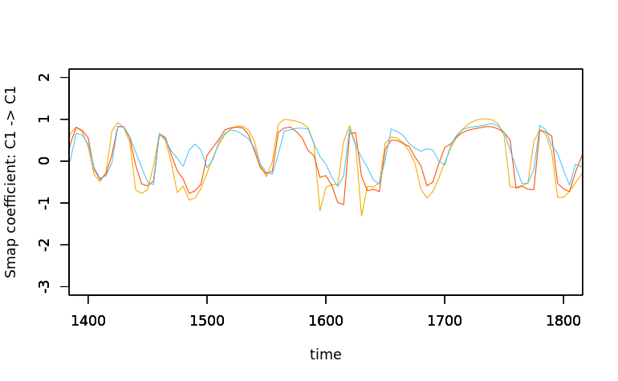

```r
plot(food_chain_result$time, food_chain_result$IIS_dC1dC1, type = "l", lty = "dashed", col = "#804000", xlim = c(1400, 1800), ylim = c(-3, 2.0), xlab = "", ylab = "")
```

##### [10.1.2] Comparison for the diagonal element (Fig. 3ab: C1 -> C1): ggplot

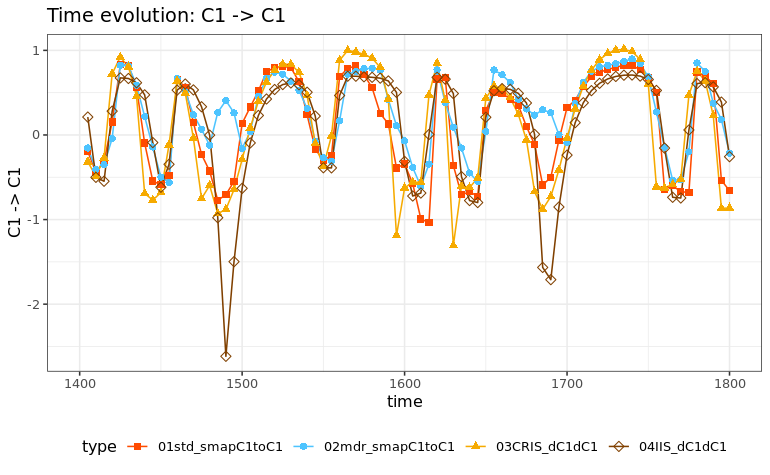

```r
fig3a_ggplot <- ggplot(data = rk4_C1toC1_ggplot) +
  scale_colour_manual(values = c("#ff4b00", "#4dc4ff", "#f6aa00", "#804000")) +
  scale_shape_manual(values = c(15, 16, 17, 5)) +
　geom_line(aes(x = time, y = IntS, group = type, color = type)) +
  geom_point(aes(x = time, y = IntS, color = type, shape = type), size = 2) +
  xlim(1400, 1800) + theme_bw() + theme(legend.position = "bottom") +
  labs(title = "Time evolution: C1 -> C1", x = "time", y = "C1 -> C1")

fig3b_ggplot <- ggplot(rk4_error_C1toC1_ggplot, aes(type, abs(IntS))) +
    scale_colour_manual(values = c("#ff4b00", "#4dc4ff", "#f6aa00", "#804000")) +
    scale_shape_manual(values = c(15, 16, 17, 5)) +
    geom_boxplot(outlier.shape = NA) +
    geom_jitter(aes(shape = type, color = type, alpha = 0.1), width = 0.25, size = 3) +
    theme_bw() + theme(legend.position = "bottom") +
    labs (title = "Comparison to direct_evaluation: C1 -> C1")

plot(fig3a_ggplot)
ggsave("fig3a.pdf", width = 6, height = 4)
```

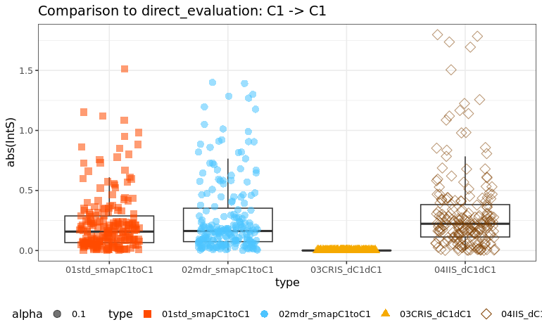

```r
plot(fig3b_ggplot)
ggsave("fig3b.pdf", width = 4, height = 4)
```

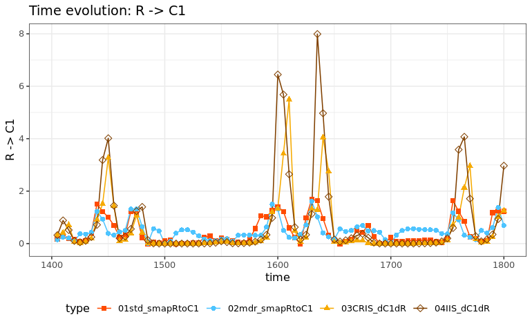

```r
fig3c_ggplot <- ggplot(data = rk4_RtoC1_ggplot) +
  scale_colour_manual(values = c("#ff4b00", "#4dc4ff", "#f6aa00", "#804000")) +
  scale_shape_manual(values = c(15, 16, 17, 5)) +
　geom_line(aes(x = time, y = IntS, group = type, color = type)) +
  geom_point(aes(x = time, y = IntS, color = type, shape = type), size = 2) +
  xlim(1400, 1800) + theme_bw() + theme(legend.position = "bottom") +
  labs(title = "Time evolution: R -> C1", x = "time", y = "R -> C1")

fig3d_ggplot <- ggplot(rk4_error_RtoC1_ggplot, aes(type, abs(IntS))) +
    scale_colour_manual(values = c("#ff4b00", "#4dc4ff", "#f6aa00", "#804000")) +
    scale_shape_manual(values = c(15, 16, 17, 5)) +
    geom_boxplot(outlier.shape = NA) +
    geom_jitter(aes(shape = type, color = type, alpha = 0.1), width = 0.25, size = 3) +
    theme_bw() + theme(legend.position = "bottom") +
    labs (title = "Comparison to direct_evaluation: R -> C1")

plot(fig3c_ggplot)
ggsave("fig3c.pdf", width = 6, height = 4)
```

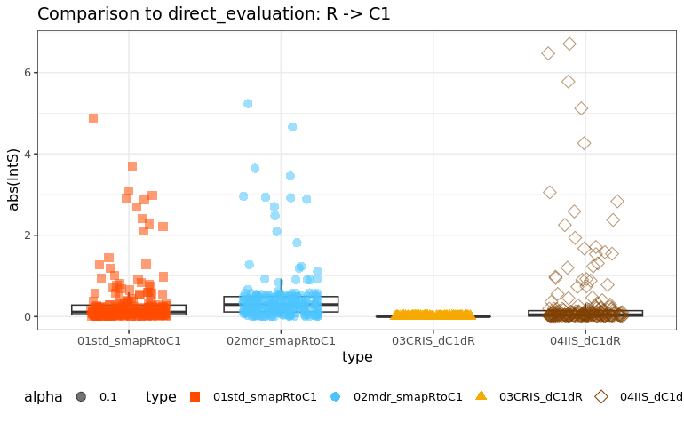

```r
plot(fig3d_ggplot)
ggsave("fig3d.pdf", width = 4, height = 4)
```

##### [10.1.4] Comparison for both diagonal and off-diagonal by correlation/regression

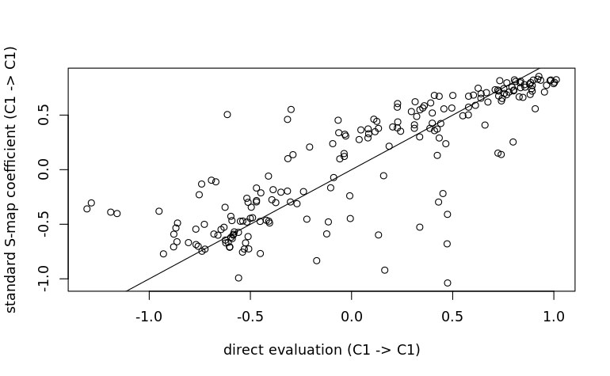

```r
#for diagonal element (C1 -> C1)
plot(food_chain_result$std_smapC1toC1 ~ food_chain_result$direct_dC1dC1,
     xlab = "direct evaluation (C1 -> C1)",
     ylab = "standard S-map coefficient (C1 -> C1)",
     )
abline(coef = c(0,1))
```

```r
cor(food_chain_result$std_smapC1toC1[-200], food_chain_result$direct_dC1dC1[-200])
```

```
[1] 0.8374068
```

```r
#Y should be the theoretical coefficient
summary(lm(food_chain_result$direct_dC1dC1[-200] ~ food_chain_result$std_smapC1toC1[-200]))
```

```
Call:
lm(formula = food_chain_result$direct_dC1dC1[-200] ~ food_chain_result$std_smapC1toC1[-200])

Residuals:
     Min       1Q   Median       3Q      Max
-1.05026 -0.17010 -0.00113  0.16673  1.45238

Coefficients:
                                       Estimate Std. Error t value Pr(>|t|)
(Intercept)                            -0.02650    0.02399  -1.105    0.271
food_chain_result$std_smapC1toC1[-200]  0.91642    0.04262  21.504   <2e-16 ***
---
Signif. codes:  0 ‘***’ 0.001 ‘**’ 0.01 ‘*’ 0.05 ‘.’ 0.1 ‘ ’ 1

Residual standard error: 0.3337 on 197 degrees of freedom
Multiple R-squared:  0.7013,    Adjusted R-squared:  0.6997
F-statistic: 462.4 on 1 and 197 DF,  p-value: < 2.2e-16
```

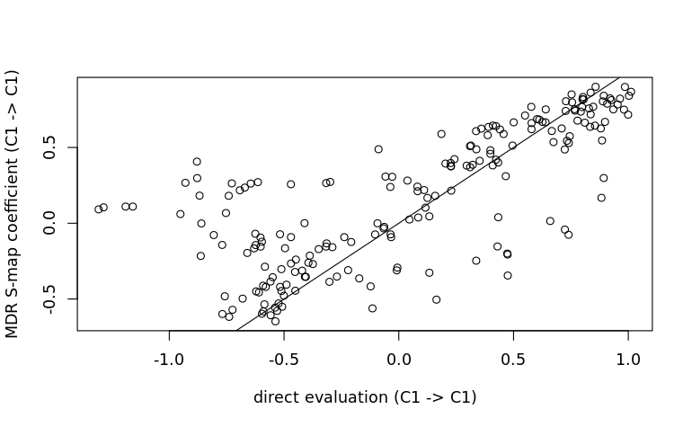

```r
plot(food_chain_result$mdr_smapC1toC1 ~ food_chain_result$direct_dC1dC1,
     xlab = "direct evaluation (C1 -> C1)",
     ylab = "MDR S-map coefficient (C1 -> C1)",
     )
abline(coef = c(0,1))
```

```r
cor(food_chain_result$mdr_smapC1toC1[-200], food_chain_result$direct_dC1dC1[-200])
```

```
[1] 0.7521856
```

```r
#Y should be the theoretical coefficient
summary(lm(food_chain_result$direct_dC1dC1[-200] ~ food_chain_result$mdr_smapC1toC1[-200]))
```

```
Call:
lm(formula = food_chain_result$direct_dC1dC1[-200] ~ food_chain_result$mdr_smapC1toC1[-200])

Residuals:
     Min       1Q   Median       3Q      Max
-1.27802 -0.08214  0.05370  0.19339  0.94716

Coefficients:
                                       Estimate Std. Error t value Pr(>|t|)
(Intercept)                            -0.12260    0.03070  -3.994 9.17e-05 ***
food_chain_result$mdr_smapC1toC1[-200]  1.01376    0.06327  16.022  < 2e-16 ***
---
Signif. codes:  0 ‘***’ 0.001 ‘**’ 0.01 ‘*’ 0.05 ‘.’ 0.1 ‘ ’ 1

Residual standard error: 0.4023 on 197 degrees of freedom
Multiple R-squared:  0.5658,    Adjusted R-squared:  0.5636
F-statistic: 256.7 on 1 and 197 DF,  p-value: < 2.2e-16
```

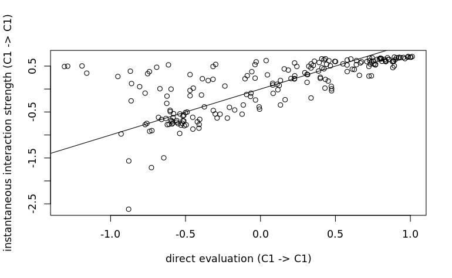

```r
plot(food_chain_result$IIS_dC1dC1 ~ food_chain_result$direct_dC1dC1,
     xlab = "direct evaluation (C1 -> C1)",
     ylab = "instantaneous interaction strength (C1 -> C1)",
     )
abline(coef = c(0,1))
```

```r
cor(food_chain_result$IIS_dC1dC1[-200], food_chain_result$direct_dC1dC1[-200])
```

```
[1] 0.7062711
```

```r
#Y should be the theoretical coefficient
summary(lm(food_chain_result$direct_dC1dC1[-200] ~ food_chain_result$IIS_dC1dC1[-200]))
```

```
Call:
lm(formula = food_chain_result$direct_dC1dC1[-200] ~ food_chain_result$IIS_dC1dC1[-200])

Residuals:
     Min       1Q   Median       3Q      Max
-1.67035 -0.13355  0.06334  0.30644  1.02468

Coefficients:
                                   Estimate Std. Error t value Pr(>|t|)
(Intercept)                        0.005217   0.030881   0.169    0.866
food_chain_result$IIS_dC1dC1[-200] 0.729854   0.052123  14.003   <2e-16 ***
---
Signif. codes:  0 ‘***’ 0.001 ‘**’ 0.01 ‘*’ 0.05 ‘.’ 0.1 ‘ ’ 1

Residual standard error: 0.4322 on 197 degrees of freedom
Multiple R-squared:  0.4988,    Adjusted R-squared:  0.4963
F-statistic: 196.1 on 1 and 197 DF,  p-value: < 2.2e-16
```

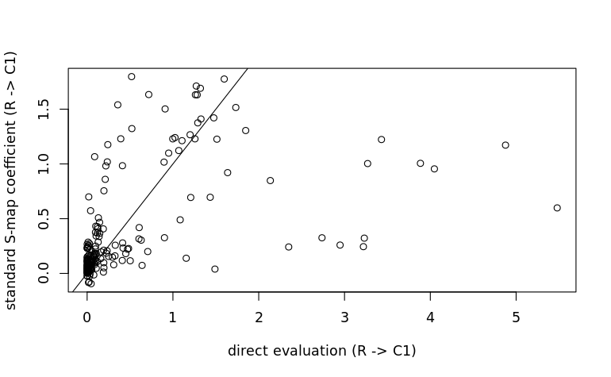

```r
#for off-diagonal element (R -> C1)
plot(food_chain_result$std_smapRtoC1 ~ food_chain_result$direct_dC1dR,
     xlab = "direct evaluation (R -> C1)",
     ylab = "standard S-map coefficient (R -> C1)",
     )
abline(coef = c(0,1))
```

```r
cor(food_chain_result$std_smapRtoC1[-200], food_chain_result$direct_dC1dR[-200])
```

```
[1] 0.5088147
```

```r
#Y should be the theoretical coefficient
summary(lm(food_chain_result$direct_dC1dR[-200] ~ food_chain_result$std_smapRtoC1[-200]))
```

```
Call:
lm(formula = food_chain_result$direct_dC1dR[-200] ~ food_chain_result$std_smapRtoC1[-200])

Residuals:
    Min      1Q  Median      3Q     Max
-1.3354 -0.2343 -0.1558 -0.0639  4.7867

Coefficients:
                                      Estimate Std. Error t value Pr(>|t|)
(Intercept)                            0.11222    0.07033   1.596    0.112
food_chain_result$std_smapRtoC1[-200]  0.96883    0.11679   8.296 1.68e-14 ***
---
Signif. codes:  0 ‘***’ 0.001 ‘**’ 0.01 ‘*’ 0.05 ‘.’ 0.1 ‘ ’ 1

Residual standard error: 0.7805 on 197 degrees of freedom
Multiple R-squared:  0.2589,    Adjusted R-squared:  0.2551
F-statistic: 68.82 on 1 and 197 DF,  p-value: 1.678e-14
```

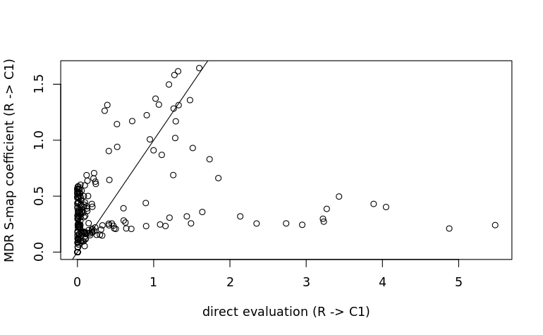

```r
plot(food_chain_result$mdr_smapRtoC1 ~ food_chain_result$direct_dC1dR,
     xlab = "direct evaluation (R -> C1)",
     ylab = "MDR S-map coefficient (R -> C1)",
     )
abline(coef = c(0,1))
```

```r
cor(food_chain_result$mdr_smapRtoC1[-200], food_chain_result$direct_dC1dR[-200])
```

```
[1] 0.2223845
```

```r
#Y should be the theoretical coefficient
summary(lm(food_chain_result$direct_dC1dR[-200] ~ food_chain_result$mdr_smapRtoC1[-200]))
```

```
Call:
lm(formula = food_chain_result$direct_dC1dR[-200] ~ food_chain_result$mdr_smapRtoC1[-200])

Residuals:
    Min      1Q  Median      3Q     Max
-0.6196 -0.4075 -0.2765 -0.0205  5.1085

Coefficients:
                                      Estimate Std. Error t value Pr(>|t|)
(Intercept)                            0.22700    0.09899   2.293  0.02290 *
food_chain_result$mdr_smapRtoC1[-200]  0.59385    0.18549   3.201  0.00159 **
---
Signif. codes:  0 ‘***’ 0.001 ‘**’ 0.01 ‘*’ 0.05 ‘.’ 0.1 ‘ ’ 1

Residual standard error: 0.884 on 197 degrees of freedom
Multiple R-squared:  0.04945,   Adjusted R-squared:  0.04463
F-statistic: 10.25 on 1 and 197 DF,  p-value: 0.001594
```

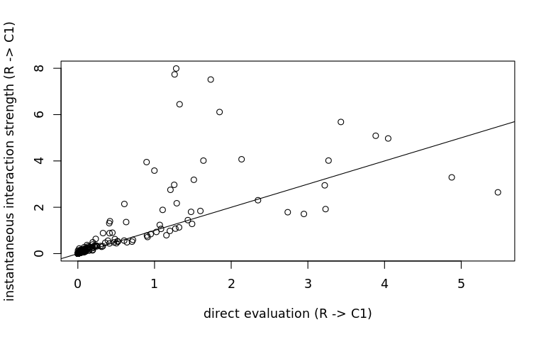

```r
plot(food_chain_result$IIS_dC1dR ~ food_chain_result$direct_dC1dR,
     xlab = "direct evaluation (R -> C1)",
     ylab = "instantaneous interaction strength (R -> C1)",
     )
abline(coef = c(0,1))
```

```r
cor(food_chain_result$IIS_dC1dR[-200], food_chain_result$direct_dC1dR[-200])
```

```
[1] 0.7100644
```

```r
#Y should be the theoretical coefficient
summary(lm(food_chain_result$direct_dC1dR[-200] ~ food_chain_result$IIS_dC1dR[-200]))
```

```
Call:
lm(formula = food_chain_result$direct_dC1dR[-200] ~ food_chain_result$IIS_dC1dR[-200])

Residuals:
    Min      1Q  Median      3Q     Max
-2.3629 -0.1519 -0.1442 -0.0614  4.1714

Coefficients:
                                  Estimate Std. Error t value Pr(>|t|)
(Intercept)                        0.15031    0.05065   2.967  0.00338 **
food_chain_result$IIS_dC1dR[-200]  0.43744    0.03091  14.154  < 2e-16 ***
---
Signif. codes:  0 ‘***’ 0.001 ‘**’ 0.01 ‘*’ 0.05 ‘.’ 0.1 ‘ ’ 1

Residual standard error: 0.6384 on 197 degrees of freedom
Multiple R-squared:  0.5042,    Adjusted R-squared:  0.5017
F-statistic: 200.3 on 1 and 197 DF,  p-value: < 2.2e-16
```